```python
# from google.colab import drive
# import os

# Mount Google Drive
# drive.mount('/content/drive')

# %cd "/content/drive/My Drive/Assignment2"
```

# CSE 258 A2: Australian Steam Bundles

## Overview

Bundles play a significant role in the Steam ecosystem, with approximately one-third of users purchasing at least one bundle, and bundled games accounting for roughly 70% of all game acquisitions (Pathak et al., 2017). This motivated our investigation into personalized bundle recommendation systems that can better capture user preferences and bundle characteristics.

We propose a solution to Steam bundle recommendation. We select datasets from the Steam video game distribution network, retrieved from https://cseweb.ucsd.edu/~jmcauley/datasets.html#steam_data.

In this notebook, we will go over the following sections:

- Exploratory Analysis on the Steam datasets
- Task Desciption, which outlines the objectives and methodology of this project
- Data Processing to formulate various data organizations
- Prediction Models, 4 approaches
- Results and Evaluation
- Related Work
- Conclusion

## Exploratory Analysis

Although reviews encompass abundant hints on what kind of games a user prefer, we opt to focus on more features pertinent to the games. As a result, we will be using 3 datasets among all:

- australian_users_items
- bundle_data
- steam_games

Please refer to the code outputs for more insights.

```python
import ast
from collections import defaultdict
import gzip
import numpy as np
import os
import pandas as pd
import matplotlib.pyplot as plt
import random
```

```python
def extract_gz(path, extraction_rate=1.00):
    with gzip.open(path, 'rt', encoding='utf-8') as f:
        n = sum(1 for _ in f)
        print(f'    Total lines: {n}')
        print(f'    Extracting {int(extraction_rate * 100)}% of lines: {int(n * extraction_rate)}')
        f.seek(0)
        dropped = set()
        if extraction_rate < 1.00:
            dropped = set(random.sample(range(1, n + 1), int(n * (1 - extraction_rate))))
        i = 0
        for line in f:
            i += 1
            if i not in dropped:
                l = line.strip()
                if l:
                    yield ast.literal_eval(l)
            if i % 1000000 == 0:
                print(f'    Processed {i} lines...')
```

```python
# Load datasets
project_path = "."
dataset_path = os.path.join(project_path, "datasets")
datasets = defaultdict(list)
extraction_rates = {
    'australian_users_items.json.gz': 1.00,
    'australian_user_reviews.json.gz': 1.00,
    'bundle_data.json.gz': 1.00,
    'steam_games.json.gz': 1.00,
    'steam_reviews.json.gz': 1.00  # Cut down this (steam_reviews) if needs to reduce size
}

for filename in os.listdir(dataset_path):
    if not filename.endswith('.gz'):
        continue
    filepath = os.path.join(dataset_path, filename)
    if not os.path.isfile(filepath):
        continue
    print(f'Loading dataset from {filepath}')
    data = []
    for d in extract_gz(filepath, extraction_rate=extraction_rates.get(filename, 1.00)):
        data.append(d)
    datasets[filename.split('.')[0]] = data
print('All datasets loaded')
```

```
Loading dataset from ./datasets/australian_users_items.json.gz
    Total lines: 88310
    Extracting 100% of lines: 88310
Loading dataset from ./datasets/australian_user_reviews.json.gz
    Total lines: 25799
    Extracting 100% of lines: 25799
Loading dataset from ./datasets/bundle_data.json.gz
    Total lines: 615
    Extracting 100% of lines: 615
Loading dataset from ./datasets/steam_games.json.gz
    Total lines: 32135
    Extracting 100% of lines: 32135
Loading dataset from ./datasets/steam_reviews.json.gz
    Total lines: 7793069
    Extracting 100% of lines: 7793069
    Processed 1000000 lines...
    Processed 2000000 lines...
    Processed 3000000 lines...
    Processed 4000000 lines...
    Processed 5000000 lines...
    Processed 6000000 lines...
    Processed 7000000 lines...
All datasets loaded
```

```python
# Display information of records per loaded dataset
sizes = {name: len(data) for name, data in datasets.items()}
if not sizes:
    print('No datasets loaded.')
else:
    sizes_series = pd.Series(sizes)
    print('Dataset sizes (number of records):')
    print(sizes_series.to_string())

    # Print a preview (first record) for each dataset
    for name in sizes_series.index:
        count = sizes[name]
        print(f'\n-- {name} - {count} records')
        if count > 0:
            # Show an untruncated representation of the first record
            preview = repr(datasets[name][0])
            print('   first record preview:', preview)
            print('   first record keys:', list(datasets[name][0].keys()))
```

```
Dataset sizes (number of records):
australian_users_items       88310
australian_user_reviews      25799
bundle_data                    615
steam_games                  32135
steam_reviews              7793069

-- australian_users_items - 88310 records
   first record preview: {'user_id': '76561197970982479', 'items_count': 277, 'steam_id': '76561197970982479', 'user_url': 'http://steamcommunity.com/profiles/76561197970982479', 'items': [{'item_id': '10', 'item_name': 'Counter-Strike', 'playtime_forever': 6, 'playtime_2weeks': 0}, {'item_id': '20'…
   first record keys: ['user_id', 'items_count', 'steam_id', 'user_url', 'items']

-- australian_user_reviews - 25799 records
   first record preview: {'user_id': '76561197970982479', 'user_url': 'http://steamcommunity.com/profiles/76561197970982479', 'reviews': [{'funny': '', 'posted': 'Posted November 5, 2011.', 'last_edited': '', 'item_id': '1250', 'helpful': 'No ratings yet', 'recommend': True, 'review': 'Simple yet wi…
   first record keys: ['user_id', 'user_url', 'reviews']

-- bundle_data - 615 records
   first record preview: {'bundle_final_price': '$66.46', 'bundle_url': 'http://store.steampowered.com/bundle/450/?utm_source=SteamDB&utm_medium=SteamDB&utm_campaign=SteamDB%20Bundles%20Page', 'bundle_price': '$73.86', 'bundle_name': 'Dharker Studio 2015 Complete', 'bundle_id': '450', 'items': [{'ge…
   first record keys: ['bundle_final_price', 'bundle_url', 'bundle_price', 'bundle_name', 'bundle_id', 'items', 'bundle_discount']

-- steam_games - 32135 records
   first record preview: {'publisher': 'Kotoshiro', 'genres': ['Action', 'Casual', 'Indie', 'Simulation', 'Strategy'], 'app_name': 'Lost Summoner Kitty', 'title': 'Lost Summoner Kitty', 'url': 'http://store.steampowered.com/app/761140/Lost_Summoner_Kitty/', 'release_date': '2018-01-04', 'tags': ['St…
   first record keys: ['publisher', 'genres', 'app_name', 'title', 'url', 'release_date', 'tags', 'discount_price', 'reviews_url', 'specs', 'price', 'early_access', 'id', 'developer']

-- steam_reviews - 7793069 records
   first record preview: {'username': 'Chaos Syren', 'hours': 0.1, 'products': 41, 'product_id': '725280', 'page_order': 0, 'date': '2017-12-17', 'text': 'This would not be acceptable as an entertainment even back in the day when these graphics were all there was to be had. No effort has been made t…
   first record keys: ['username', 'hours', 'products', 'product_id', 'page_order', 'date', 'text', 'early_access', 'page']
```

```
Computing items count distribution for `australian_users_items`
Min items count: 0
Max items count: 7762
```

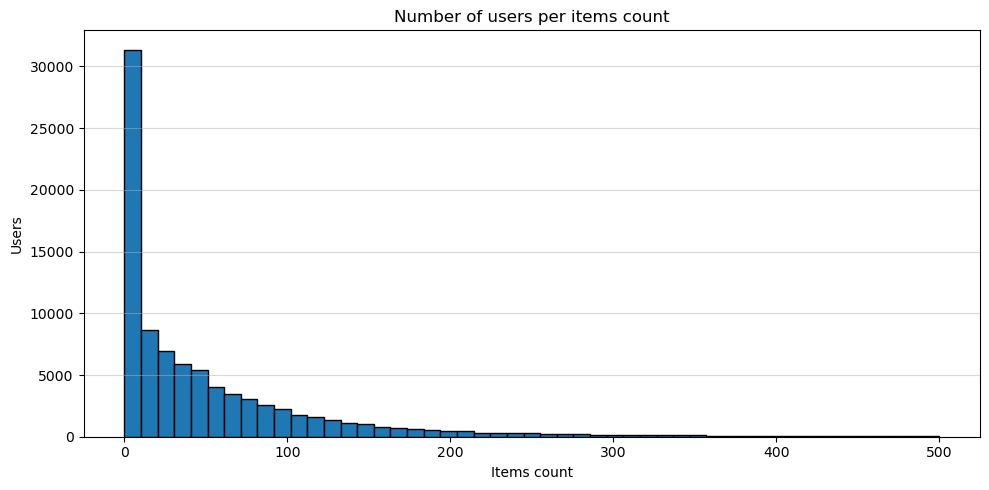

```python
# Compute items count distribution for australian_user_items
aui = datasets.get('australian_users_items', [])
if not aui:
    print('`australian_users_items` is not loaded.')
else:
    print('Computing items count distribution for `australian_users_items`')
    items_counts = []
    for r in aui:
        if isinstance(r, dict):
            # Prefer an explicit items_count field when available
            if 'items_count' in r and isinstance(r['items_count'], (int, float)):
                items_counts.append(int(r['items_count']))
            elif 'items' in r and isinstance(r['items'], (list, tuple)):
                items_counts.append(len(r['items']))
    if not items_counts:
        print('No items count values available in records.')
    else:
        min_count = int(min(items_counts))
        max_count = int(max(items_counts))
        print(f'Min items count: {min_count}')
        print(f'Max items count: {max_count}')
        bins = np.linspace(0, 500, 50)
        plt.figure(figsize=(10, 5))
        plt.hist(items_counts, bins=bins, edgecolor='black')
        plt.xlabel('Items count')
        plt.ylabel('Users')
        plt.title('Number of users per items count')
        plt.grid(axis='y', alpha=0.5)
        plt.tight_layout()
        plt.show()
```

```
Computing items count distribution for `bundle_data`
Min items count: 2
Max items count: 89
```

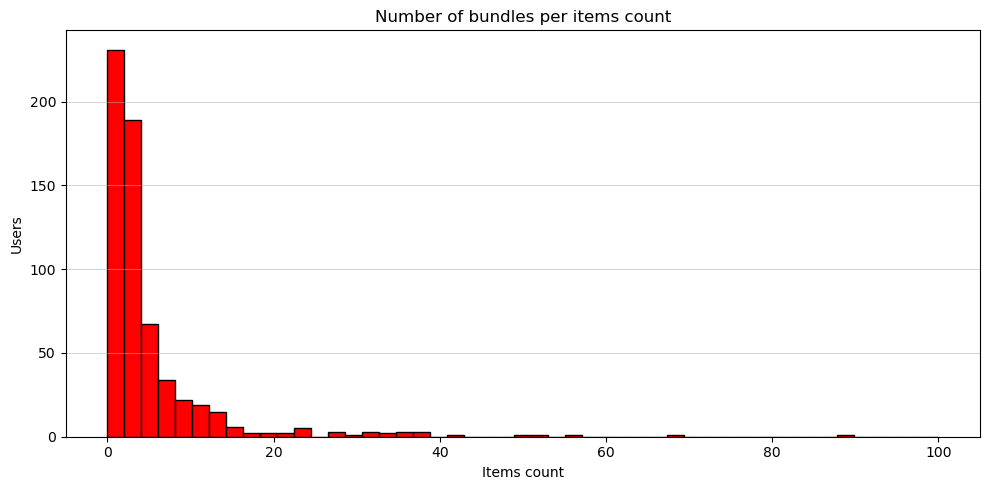

```python
# Compute items count distribution for australian_user_items
bd = datasets.get('bundle_data', [])
if not bd:
    print('`bundle_data` is not loaded.')
else:
    print('Computing items count distribution for `bundle_data`')
    items_counts = []
    for r in bd:
        if isinstance(r, dict):
            # Prefer an explicit items_count field when available
            if 'items_count' in r and isinstance(r['items_count'], (int, float)):
                items_counts.append(int(r['items_count']))
            elif 'items' in r and isinstance(r['items'], (list, tuple)):
                items_counts.append(len(r['items']))
    if not items_counts:
        print('No items count values available in records.')
    else:
        min_count = int(min(items_counts))
        max_count = int(max(items_counts))
        print(f'Min items count: {min_count}')
        print(f'Max items count: {max_count}')
        bins = np.linspace(0, 100, 50)
        plt.figure(figsize=(10, 5))
        plt.hist(items_counts, bins=bins, color='red', edgecolor='black')
        plt.xlabel('Items count')
        plt.ylabel('Users')
        plt.title('Number of bundles per items count')
        plt.grid(axis='y', alpha=0.5)
        plt.tight_layout()
        plt.show()
```

## Task Description

### 1. Predictive Task

The objective of this project is to build a **personalized bundle recommendation system for Steam users**. Given a user’s historical game library, playtime behavior, and the catalog of available game bundles, the predictive task is:

> **For a given user *u*, estimate the probability that they will be interested in (or likely to purchase) a bundle *b*.**

Formally, we aim to learn: $$\hat{y}_{u,b} = f(u, b),$$ where $\hat{y}_{u,b}$ represents the predicted affinity score of user $u$ for bundle $b$.

#### Why This Task Matters

Steam bundles provide users with discounted collections of games. Accurate bundle recommendations:

- increase Steam’s revenue by promoting bundles users are likely to purchase,
- help users find relevant bundles at lower prices,
- improve overall user satisfaction and discovery.

This task aligns well with course content on recommendation systems, ranking models, and evaluation of predictors using implicit feedback.

### 2. Baseline and Model Overview

- **Logistic Regression Baseline**

User–bundle interactions are represented using one-hot and numerical features (e.g., bundle popularity, item overlap, user activity). A logistic regression classifier is trained to predict whether a user would choose a bundle. This provides a simple linear baseline.

- **Bayesian Personalized Ranking (BPR)**

A collaborative-filtering model that learns user and bundle representations by optimizing pairwise ranking loss. BPR directly models user preferences by ensuring that observed (positive) bundles are ranked higher than unobserved ones. This provides a personalized recommendation baseline grounded in latent factor modeling.

- **Latent Facotr Model**

Users and bundles are embedded into a shared latent space. Their interaction score is computed via dot product. This captures hidden preference patterns with minimal complexity.

- **Neural Collaborative Filtering**

A more expressive collaborative model that uses nonlinear layers to learn user–bundle interactions. It provides a deeper baseline that bridges traditional MF and neural models

### 3. Assessing the Validity of Model Predictions

We will evaluate the validity of our recommendation models using standard metrics for implicit-feedback ranking tasks:

Together, these evaluations provide a robust assessment of both ranking accuracy and practical top-K recommendation quality.

## Data Processing

### Steam Bundle Preprocessing Pipeline

The following code is the full preprocessing pipeline used to transform raw Steam datasets into structured user–bundle, user–item, and bundle–item mappings. It consolidates item metadata, filters invalid entries, generates training/test splits, and saves all processed data as JSON files.

### 1. Input Datasets

The script loads three raw datasets:

#### Dataset Roles

- australian_users_items — list of users and the items they own.
- bundle_data — each bundle contains a list of item IDs.
- steam_games — full metadata for each game.

```python
aus_items   = datasets['australian_users_items']
bundle_raw  = datasets['bundle_data']
games_raw   = datasets['steam_games']
```

### 2. Collect All Unique Item IDs

Item IDs are collected from:

- user item lists
- bundle item lists

A helper function parses bundle item ID strings, ensuring all valid numeric IDs are included.

```python
item_ids = set()
for u in aus_items:
    for it in u.get("items", []):
        item_ids.add(str(it["item_id"]))

def parse_bundle_item_ids(raw_id):
    if raw_id is None:
        return []
    s = str(raw_id).strip()
    if not s:
        return []

    appids = []
    for part in s.split(','):
        p = part.strip()
        if p.isdigit():
            appids.append(p)
    return appids

for b in bundle_raw:
    for it in b.get("items", []):
        for appid in parse_bundle_item_ids(it.get("item_id")):
            item_ids.add(appid)

game_by_id = {}
for g in games_raw:
    if "id" in g:
        item_ids.add(str(g["id"]))
        game_by_id[str(g["id"])] = g
```

### 3. Build Game Metadata Table

For each item ID:

- Extract metadata fields: title, genres, tags, price, release_date, etc.
- Handle missing fields with defaults.
- Create lookup tables:
  - item_id_lookup[appid] = index
  - appid2idx[index] = appid

Items are sorted by integer appid.

```python
sorted_ids = sorted(item_ids, key=lambda x: int(x))
item_id_lookup = {idx: int(appid) for idx, appid in enumerate(sorted_ids)}
appid2idx = {appid: idx for idx, appid in enumerate(sorted_ids)}
items_set = set(range(len(sorted_ids)))
item_data = []
for appid in sorted_ids:
    g = game_by_id.get(appid)
    if g is None:
        info = {
            "appid": appid,
            "title": None,
            "genres": [],
            "tags": [],
            "price": None,
            "discount_price": None,
            "release_date": None,
            "early_access": None,
            "developer": None,
            "publisher": None,
        }
    else:
        info = {
            "appid": appid,
            "title": g.get("title") or g.get("app_name"),
            "genres": g.get("genres", []),
            "tags": g.get("tags", []),
            "price": g.get("price"),
            "discount_price": g.get("discount_price"),
            "release_date": g.get("release_date"),
            "early_access": g.get("early_access"),
            "developer": g.get("developer"),
            "publisher": g.get("publisher"),
        }
    item_data.append(info)
```

### 4. Build Bundle → Items Mapping

For each bundle:

```
bundle_item_map[bundle_idx] = {item_idx1, item_idx2, ...}
```

Only valid items are kept.

Additional lookup tables:

- bundle_id2idx
- idx2bundle_id

```python
bundle_item_map = defaultdict(set)
bundle_item_map_bpr = defaultdict(set)
bundle_id2idx = {}
idx2bundle_id = {}

for b_idx, b in enumerate(bundle_raw):
    bundle_id = str(b["bundle_id"])
    bundle_id2idx[bundle_id] = b_idx
    idx2bundle_id[b_idx] = bundle_id

    bundle_item_map[b_idx] = set()  # <-- ensure key exists even if empty

    for it in b.get("items", []):
        appid = str(it["item_id"])
        if appid in appid2idx:
            item_idx = appid2idx[appid]
            bundle_item_map[b_idx].add(item_idx)
            bundle_item_map_bpr[b_idx].add(item_idx)  # for BPR model
```

### 5. Build User → Items Mapping

For each user:

```
user_item_map[user_idx] = {item_idx1, item_idx2, ...}
```

Only valid items are added.

Mappings:

- user_id2idx
- idx2user_id

```python
user_item_map = defaultdict(set)
user_item_map_bpr = defaultdict(set)
user_id2idx = {}
idx2user_id = {}

for u_idx, u in enumerate(aus_items):
    uid = str(u["user_id"])
    user_id2idx[uid] = u_idx
    idx2user_id[u_idx] = uid

    user_item_map[u_idx] = set()

    for it in u.get("items", []):
        appid = str(it["item_id"])
        if appid in appid2idx:
            item_idx = appid2idx[appid]
            user_item_map[u_idx].add(item_idx)
            user_item_map_bpr[u_idx].add(item_idx)  # for BPR model
```

### 6. Filter Invalid Users & Bundles

Keep only:

- users with ≥ 1 owned item
- bundles containing ≥ 1 valid item

This produces:

- filtered_users
- filtered_bundles

New compact ID mappings are created.

### 7. Rebuild Maps with New IDs

Maps reconstructed:

- new_user_item_map
- new_bundle_item_map

Using only filtered entities and new indices.

```python
filtered_users = []
for u_idx, items in user_item_map.items():
    if len(items) > 0:
        filtered_users.append(u_idx)

filtered_bundles = []
for b_idx, items in bundle_item_map.items():
    if len(items) > 0:
        filtered_bundles.append(b_idx)

new_user_id = {old_u: new_u for new_u, old_u in enumerate(filtered_users)}
new_bundle_id = {old_b: new_b for new_b, old_b in enumerate(filtered_bundles)}

num_users   = len(filtered_users)
num_bundles = len(filtered_bundles)
num_items   = len(appid2idx)

new_user_item_map = defaultdict(set)
for old_u in filtered_users:
    new_u = new_user_id[old_u]
    new_user_item_map[new_u] = set(user_item_map[old_u])

new_bundle_item_map = defaultdict(set)
for old_b in filtered_bundles:
    new_b = new_bundle_id[old_b]
    new_bundle_item_map[new_b] = set(bundle_item_map[old_b])

bundle_items_list = new_bundle_item_map

print(num_users)
print(num_bundles)
print(num_items)
```

```
71504
613
34239
```

### 8. Build User → Bundle Ownership Mapping

A user owns a bundle if **all bundle items** are a subset of the user’s owned items:

```
if b_items.issubset(items):
    user_bundle_map[u].add(b)
```

This rule defines the ground-truth user-bundle interactions

```python
user_bundle_map_bpr = defaultdict(set)
bundle_items_list_bpr = list(bundle_item_map_bpr.items())
for u_idx, items_owned in user_item_map_bpr.items():
    if not items_owned:
        continue
    for b_idx, b_items in bundle_items_list_bpr:
        if b_items and b_items.issubset(items_owned):
            user_bundle_map_bpr[u_idx].add(b_idx)

user_bundle_map = defaultdict(set)
for u, items in new_user_item_map.items():
    for b, b_items in new_bundle_item_map.items():
        if b_items.issubset(items):  # user owns all games in bundle
            user_bundle_map[u].add(b)
```

### 9. Construct Training/Test set

Split 80/20 Training/Test set

#### Prevent data leakage

Build training-only map:

- user_bundle_map_train

```python
item_data_map=dict()
tags_set=set()
for item in item_data:
    item_data_map[int(item['appid'])]=item
    for tag in item['tags']:
        tags_set.add(tag)
tags_map=dict()
for i,tag in enumerate(tags_set):
    tags_map[tag]=i
def get_feat(tags):
    feat=np.zeros(len(tags_map))
    for tag in tags:
        feat[tags_map[tag]]=1
    return feat

# BPR data preparation

all_data_bpr=[]

for user,bundles in user_bundle_map_bpr.items():
    for bundle in bundles:
        all_data_bpr.append((user,bundle))

all_item_data_bpr=[]
for user,items in user_item_map_bpr.items():
    for item in items:
        all_item_data_bpr.append((user,item))

random.shuffle(all_data_bpr)
data_size=len(all_data_bpr)

training_data_bpr=all_data_bpr[:int(0.8*data_size)]
test_data_bpr=all_data_bpr[int(0.8*data_size):]

user_bundle_map_train_bpr = defaultdict(set)
for user, bundle in training_data_bpr:
    user_bundle_map_train_bpr[user].add(bundle)

# Common data preparation

all_data=[]

for user,bundles in user_bundle_map.items():
    for bundle in bundles:
        all_data.append((user,bundle))

all_item_data=[]
for user,items in user_item_map.items():
    for item in items:
        all_item_data.append((user,item))

random.shuffle(all_data)
data_size=len(all_data)

training_data=all_data[:int(0.8*data_size)]
test_data=all_data[int(0.8*data_size):]

# Create training-only user_bundle_map to avoid data leakage
# This map only contains user-bundle pairs from training_data
user_bundle_map_train = defaultdict(set)
# user_item_map_train = defaultdict(set)

for user, bundle in training_data:
    user_bundle_map_train[user].add(bundle)
    # items_in_bundle = new_bundle_item_map[bundle]
    # user_item_map_train[user].update(items_in_bundle)

print(f"Total user-bundle pairs: {len(all_data)}")
print(f"Training pairs: {len(training_data)} ({len(training_data)/len(all_data)*100:.1f}%)")
print(f"Test pairs: {len(test_data)} ({len(test_data)/len(all_data)*100:.1f}%)")
print(f"Training users in map: {len(user_bundle_map_train)}")
print(f"Total users in full map: {len(user_bundle_map)}")
```

```
Total user-bundle pairs: 102520
Training pairs: 82016 (80.0%)
Test pairs: 20504 (20.0%)
Training users in map: 31554
Total users in full map: 34460
```

### 10. Save Processed Data as JSON

Saved to:

```
pgsql
./data/processed_json/
```

All structures serialized to JSON-friendly format.

#### Output Files

| File | Description |
| --- | --- |
| item_set.json | list of all item IDs |
| item_id_lookup.json | item_id → index |
| all_items.json | cleaned metadata for each item |
| user_item_map.json | user → items owned |
| user_bundle_map.json | user → bundles owned |
| bundle_item_map.json | bundle → items contained |

```python
import os, json
SAVE_DIR = "./data/processed_json"
os.makedirs(SAVE_DIR, exist_ok=True)

def to_jsonable(obj):
    if isinstance(obj, set):
        return list(obj)
    if hasattr(obj, "tolist"):
        return obj.tolist()
    if isinstance(obj, dict):
        return {str(k): to_jsonable(v) for k, v in obj.items()}
    if isinstance(obj, (list, tuple)):
        return [to_jsonable(x) for x in obj]
    return obj

def save_json(obj, filename):
    filepath = os.path.join(SAVE_DIR, filename)
    with open(filepath, "w", encoding="utf-8") as f:
        json.dump(to_jsonable(obj), f, ensure_ascii=False, indent=2)
    print(f"[saved] {filepath}")
```

```python
save_json(items_set, "item_set.json")
save_json(item_id_lookup, "item_id_lookup.json")
save_json(item_data, "all_items.json")
save_json(user_item_map, "user_item_map.json")
save_json(user_bundle_map, "user_bundle_map.json")
save_json(bundle_item_map, "bundle_item_map.json")
```

```
[saved] ./data/processed_json/item_set.json
[saved] ./data/processed_json/item_id_lookup.json
[saved] ./data/processed_json/all_items.json
[saved] ./data/processed_json/user_item_map.json
[saved] ./data/processed_json/user_bundle_map.json
[saved] ./data/processed_json/bundle_item_map.json
```

### 11. Graph Sampling

#### 1. Purpose of the Sampling Procedure

`graph_sampling` generates **user–positive–negative triplets** , based on the user–bundle bipartite graph.

- `training_data` contains only **positive edges** (`user`, `bundle`) where the user truly owns the bundle.
- The function creates negative samples (`user`, `negative_bundle`) such that:
  - the user does **not** own the negative bundle,
  - the negative bundle is *"reasonably hard"* (i.e., not random noise),
  - the samples are balanced and consistent across users.

This function takes advantage of graph structure instead of uniformly random sample

#### 2. `check_tuple`: Verifying a Valid Pair of Edges

For two positive edges:

```
tuple_1 = (u1, b1)
tuple_2 = (u2, b2)
```

The function:

```
tuple_1[1] not in user_bundle_map[tuple_2[0]]
and
tuple_2[1] not in user_bundle_map[tuple_1[0]]
```

means:

- `b1` is **not owned** by `u2`
- `b2` is **not owned** by `u1`

If both conditions hold, then:

- `(u1, b2)` is a valid negative sample
- `(u2, b1)` is also a valid negative sample

Thus, one valid pair of edges produces **two symmetric training samples**:

1. `(u1, pos=b1, neg=b2)`
2. `(u2, pos=b2, neg=b1)`

This makes sampling more efficient and yields harder negatives compared to global random sampling.

#### 3. Inputs and Outputs

| Argument | Meaning |
| --- | --- |
| `n_samples` | Number of triplets to generate (must be even, function creates 2 per iteration) |
| `training_data` | List of positive user–bundle pairs (`user`, `bundle`) |
| `user_bundle_map` | Mapping `user → set(bundles)` for fast membership tests |

#### Outputs

The function returns three lists:

- `sgd_users[k]` — user ID
- `sgd_pos_items[k]` — positive bundle
- `sgd_neg_items[k]` — negative bundle

For each index `k`, **(`sgd_users[k]`, `sgd_pos_items[k]`, `sgd_neg_items[k]`) forms a valid training triplet.**

#### 4. Why This is Called Graph-Based Sampling

The method works directly on the **user–bundle bipartite graph**:

- Positive edges = observed interactions
- Negative edges = inferred missing edges
- Sampling considers **graph structure**, not random guessing
- A valid pair of positive edges must satisfy structural constraints

This produces **"hard negatives"**, superior to naive random selection.

#### 5. Advantages Over Traditional Negative Sampling

| Method | Description | Weakness |
| --- | --- | --- |
| Global random sampling | Pick a random bundle → check if user doesn’t own it | Often produces trivial negatives |
| Uniform per-user sampling | Random from bundles not owned | Still mostly easy negatives; ignores graph structure |
| **Graph sampling (this method)** | Uses cross-edge inference to generate hard negatives | More computationally expensive |

Graph sampling yields:

- Harder negatives
- Higher-quality gradients
- Better ranking performance
- Balanced sampling (every valid tuple generates 2 samples)

#### 6. Potential Limitations

1. **Efficiency** If the graph is dense, many random pairs might fail the `check_tuple` test.
2. **Sample imbalance** Users with many interactions appear more often because sampling is edge-based.
3. **`n_samples` must be even** Each iteration contributes exactly **2 samples**.
4. **High variance** Since sampling is random, results vary unless seed is fixed.

The following code is reproduced and edited from the official implementation of Pathak et al. [3]：

```python
def check_tuple(tuple_1, tuple_2, user_bundle_map):
    return tuple_1[1] not in user_bundle_map[tuple_2[0]] and tuple_2[1] not in user_bundle_map[tuple_1[0]]
```

```python
def graph_sampling(n_samples, training_data, user_bundle_map):
    sgd_users=[]
    sgd_pos_items, sgd_neg_items = [], []
    i=0
    while n_samples>0:
        if i%100000==0:
            print(i)
        i+=1
        tuple_1=training_data[np.random.randint(len(training_data))]
        tuple_2=training_data[np.random.randint(len(training_data))]
        iteration=100
        while not check_tuple(tuple_1, tuple_2, user_bundle_map):
            tuple_2=training_data[np.random.randint(len(training_data))]
            iteration-=1
            if iteration == 0:
                break
        if iteration==0:
            continue
        sgd_neg_items.append(tuple_2[1])
        sgd_pos_items.append(tuple_1[1])
        sgd_users.append(tuple_1[0])

        sgd_neg_items.append(tuple_1[1])
        sgd_pos_items.append(tuple_2[1])
        sgd_users.append(tuple_2[0])
        n_samples-=2
    return sgd_users, sgd_pos_items, sgd_neg_items
```

```python
sgd_users_train, sgd_pos_bundles_train, sgd_neg_bundles_train = graph_sampling(
    len(training_data)*30, training_data, user_bundle_map_train
)
```

```
0
100000
200000
300000
400000
500000
600000
700000
800000
900000
1000000
1100000
1200000
```

```python
def item_sampling(n_samples, all_item_data, user_item_map):
    sgd_users=[]
    sgd_pos_items, sgd_neg_items = [], []
    i=0
    while n_samples>0:
        if i%100000==0:
            print(i)
        i+=1
        tuple_1=all_item_data[np.random.randint(len(all_item_data))]
        tuple_2=all_item_data[np.random.randint(len(all_item_data))]
        iteration=100
        while not tuple_1[1] not in user_item_map[tuple_2[0]] and tuple_2[1] not in user_item_map[tuple_1[0]]:
            tuple_2=all_item_data[np.random.randint(len(all_item_data))]
            iteration-=1
            if iteration == 0:
                break
        if iteration==0:
            continue
        sgd_neg_items.append(tuple_2[1])
        sgd_pos_items.append(tuple_1[1])
        sgd_users.append(tuple_1[0])

        sgd_neg_items.append(tuple_1[1])
        sgd_pos_items.append(tuple_2[1])
        sgd_users.append(tuple_2[0])
        n_samples-=2
    return sgd_users, sgd_pos_items, sgd_neg_items
```

```python
item_sgd_users, sgd_pos_items, sgd_neg_items = item_sampling(len(all_item_data_bpr), all_item_data_bpr, user_item_map_bpr)
```

```
0
100000
200000
300000
400000
500000
600000
700000
800000
900000
1000000
1100000
1200000
1300000
1400000
1500000
1600000
1700000
1800000
1900000
2000000
2100000
2200000
2300000
2400000
2500000
```

### 12. Train/Validation/Test Triplet Generation

#### 1. Training & Validation Triplets

Triplets are generated from `training_data` using **training-only user–bundle map** (`user_bundle_map_train`), which prevents information from test sets leaking into the sampling process.

#### Train/Val Split

We split the triplets (from the 80% train portion) into:

- **70% train**
- **10% validation**

#### 2. Test Triplets (From Test Data)

Test triplets are generated from `test_data` only.

```python
# Generate train/val triples from training_data using training-only map
print("Generating train/val triples from training data...")

train_val_triples = list(zip(sgd_users_train, sgd_pos_bundles_train, sgd_neg_bundles_train))
random.shuffle(train_val_triples)

# 70-10 split for train-val (from training_data)
train_val_split = int(0.875 * len(train_val_triples))
train_triples = train_val_triples[:train_val_split]
val_triples   = train_val_triples[train_val_split:]

print("Generating test triples from held-out test data...")
sgd_users_test, sgd_pos_bundles_test, sgd_neg_bundles_test = graph_sampling(
    len(test_data)*30, test_data, user_bundle_map
)

test_triples = list(zip(sgd_users_test, sgd_pos_bundles_test, sgd_neg_bundles_test))
random.shuffle(test_triples)

train_users  = [t[0] for t in train_triples]
train_pos    = [t[1] for t in train_triples]
train_neg    = [t[2] for t in train_triples]

val_users    = [t[0] for t in val_triples]
val_pos      = [t[1] for t in val_triples]
val_neg      = [t[2] for t in val_triples]

test_users   = [t[0] for t in test_triples]
test_pos     = [t[1] for t in test_triples]
test_neg     = [t[2] for t in test_triples]

total_triples = len(train_triples) + len(val_triples) + len(test_triples)
print(f"\nSplit Summary:")
print(f"Train: {len(train_triples)} triples ({len(train_triples)/total_triples*100:.1f}%)")
print(f"Val: {len(val_triples)} triples ({len(val_triples)/total_triples*100:.1f}%)")
print(f"Test: {len(test_triples)} triples ({len(test_triples)/total_triples*100:.1f}%)")
print(f"\nIMPORTANT: Test triples are generated from held-out test_data to avoid data leakage!")
```

```
Generating train/val triples from training data...
Generating test triples from held-out test data...
0
100000
200000
300000

Split Summary:
Train: 2152920 triples (70.0%)
Val: 307560 triples (10.0%)
Test: 615120 triples (20.0%)

IMPORTANT: Test triples are generated from held-out test_data to avoid data leakage!
```

### 13. Data Leakage Check

To ensure a clean evaluation, we verify that **test triplets do not overlap** with training data.

```python
# Verify no data leakage: Check that test triples don't overlap with training data
print("="*60)
print("DATA LEAKAGE CHECK")
print("="*60)

# Convert training_data to set for fast lookup
training_data_set = set(training_data)
test_data_set = set(test_data)

# Check test triples
test_pos_pairs = set(zip(test_users, test_pos))
test_neg_pairs = set(zip(test_users, test_neg))

# Count overlaps
train_pos_overlap = len(test_pos_pairs & training_data_set)
train_neg_overlap = len(test_neg_pairs & training_data_set)

print(f"Test positive pairs that appear in training_data: {train_pos_overlap}")
print(f"Test negative pairs that appear in training_data: {train_neg_overlap}")
print(f"Total test positive pairs: {len(test_pos_pairs)}")
print(f"Total test negative pairs: {len(test_neg_pairs)}")

if train_pos_overlap == 0 and train_neg_overlap == 0:
    print("\n✓ NO DATA LEAKAGE DETECTED: Test set is properly isolated!")
else:
    print(f"\n⚠ WARNING: Found {train_pos_overlap + train_neg_overlap} overlapping pairs!")
    print("This indicates potential data leakage.")

# Check that test_data doesn't overlap with training_data
overlap = len(training_data_set & test_data_set)
print(f"\nOverlap between training_data and test_data: {overlap}")
if overlap == 0:
    print("✓ Training and test data are properly separated!")
else:
    print(f"⚠ WARNING: Found {overlap} overlapping user-bundle pairs!")

print("="*60)
```

```
============================================================
DATA LEAKAGE CHECK
============================================================
Test positive pairs that appear in training_data: 0
Test negative pairs that appear in training_data: 0
Total test positive pairs: 20504
Total test negative pairs: 163877

✓ NO DATA LEAKAGE DETECTED: Test set is properly isolated!

Overlap between training_data and test_data: 0
✓ Training and test data are properly separated!
============================================================
```

## Prediction Model

### **(A) Baseline Model: Logistic Regression**

#### 1. Constructing Training and Test Pairs

We first turn the sampled triplets into a binary classification dataset.

- Each pair `(u, b)` is a **user–bundle pair**.
- Labels:
  - `y = 1` if the bundle is sampled as the positive bundle for that user.
  - `y = 0` if the bundle is a sampled negative bundle.
- At the same time, we maintain:
  - `bundle_pop_counter[b]` — how many times bundle `b` appears as a positive sample (a proxy for popularity).
  - `user_activity_counter[u]` — how many positive interactions user `u` has (a proxy for user activity).

#### 2. Popularity and Activity Features

We normalize bundle popularity and user activity to $[0, 1]$:

For bundle $b$ with positive count $c_b$:

$$ \text{pop}(b) = \frac{c_b}{\max_{b'} c_{b'}} \in [0, 1] $$

For user $u$ with positive count $c_u$:

$$ \text{act}(u) = \frac{c_u}{\max_{u'} c_{u'}} \in [0, 1] $$

These become two global scalar features for each user–bundle pair.

```python
from collections import Counter
X_train_pairs = []
y_train = []
X_test_pairs = []
y_test = []

bundle_pop_counter = Counter()
user_activity_counter = Counter()

for u, b_pos, b_neg in zip(sgd_users_train, sgd_pos_bundles_train, sgd_neg_bundles_train):
    X_train_pairs.append([u, b_pos])
    y_train.append(1)
    bundle_pop_counter[b_pos] += 1
    user_activity_counter[u] += 1
    X_train_pairs.append([u, b_neg])
    y_train.append(0)

for u, b_pos, b_neg in zip(sgd_users_test, sgd_pos_bundles_test, sgd_neg_bundles_test):
    X_test_pairs.append([u, b_pos])
    y_test.append(1)
    X_test_pairs.append([u, b_neg])
    y_test.append(0)

X_train_pairs = np.array(X_train_pairs)
y_train = np.array(y_train)
X_test_pairs = np.array(X_test_pairs)
y_test = np.array(y_test)

max_pop = max(bundle_pop_counter.values()) if bundle_pop_counter else 1.0
bundle_popularity = {int(b): float(c) / max_pop for b, c in bundle_pop_counter.items()}

max_act = max(user_activity_counter.values()) if user_activity_counter else 1
user_activity = {int(u): c / max_act for u, c in user_activity_counter.items()}
```

#### 3. Categorical Features: One-Hot Encoding of (User, Bundle)

We treat the `(user_id, bundle_id)` pair as a purely categorical feature and one-hot encode it.

- Each column in `X_train_cat` corresponds to a user or bundle category (depending on how `OneHotEncoder` is configured).
- This captures **ID-specific biases** similar to standard one-hot logistic regression.

```python
from sklearn.preprocessing import OneHotEncoder

enc = OneHotEncoder(handle_unknown='ignore')

X_all_pairs = np.vstack([X_train_pairs, X_test_pairs])
enc.fit(X_all_pairs)

X_train_cat = enc.transform(X_train_pairs)
X_test_cat  = enc.transform(X_test_pairs)
```

#### 4. Numeric Features: Popularity, Activity, Bundle Size, Coverage

We also build a set of numeric features based on graph statistics. For each pair ((u, b)) we compute:

1. **Bundle popularity** $\text{pop}(b)$ (defined above).
2. **User activity** $\text{act}(u)$.
3. **Bundle size** — number of individual games in bundle $b$:

$$ \text{size}(b) = |I(b)| $$

4. **Coverage** — how much of the bundle the user already owns:

$$ \text{cov}(u, b) = \begin{cases} \frac{|I(u) \cap I(b)|}{|I(b)|}, & |I(b)| > 0 \\ 0, & \text{otherwise} \end{cases} $$

where $I(u)$ is the set of items owned by user $u$, and $I(b)$ is the set of items contained in bundle $b$.

All numeric features are standardized using `StandardScaler`:

$$ x' = \frac{x - \mu}{\sigma} $$

so each dimension has approximately zero mean and unit variance.

```python
from sklearn.preprocessing import StandardScaler
def build_numeric_features(pairs):
    users = pairs[:, 0]
    bundles = pairs[:, 1]

    pop_list = []
    act_list = []
    size_list = []
    cov_list = []

    for u, b in zip(users, bundles):
        pop_list.append(bundle_popularity.get(int(b), 0.0))
        act_list.append(user_activity.get(int(u), 0.0))

        b_item = bundle_items_list.get(int(b), 0.0)
        size = len(b_item)

        u_item = user_item_map.get(int(u), 0.0)
        if size > 0:
            cov = len(u_item & b_item) / float(size)
        else:
            cov = 0
        size_list.append(size)
        cov_list.append(cov)

    return np.vstack([pop_list, act_list, size_list, cov_list]).T

num_train = build_numeric_features(X_train_pairs)
num_test  = build_numeric_features(X_test_pairs)

scaler = StandardScaler()
num_train_scaled = scaler.fit_transform(num_train)
num_test_scaled  = scaler.transform(num_test)
```

#### 5. Final Feature Matrix — Why Graph-Sampling Matters

After building both the categorical (one-hot) and numeric features, we concatenate them into a single sparse feature matrix.

To inspect how informative the numeric features are, we compare the mean values of positives vs. negatives:

[output not shown]

##### 1. Why are positive and negative distributions almost identical?

This behavior highlights an important property of **graph-sampling**, especially the cross-edge hard negative sampling used earlier:

✔ Hard negatives are sampled to closely resemble positive samples Because each negative bundle was chosen by **crossing** two real positive edges $(u1, b1)$ and $(u2, b2)$, the negative bundle:

- is popular enough to appear in the graph,
- occurs as a positive example for another user,
- often has similar bundle size,
- may contain overlapping items to the user's history.

Thus the negative samples are **not random uninformed negatives**, but **hard negatives** that share similar feature statistics with true positives.

Formally, for any negative sample $(u_1, b_2)$, we know that $b_2$ was a **positive** bundle for some user $u_2$:

$$ b_2 \in \mathrm{B}(u_2), \qquad b_2 \notin \mathrm{B}(u_1) $$

Because of this, distributions satisfy approximately:

$$ \mathbb{E}[\text{pop}(b) \mid y = 1] \approx \mathbb{E}[\text{pop}(b) \mid y = 0] $$

and similarly for `size`, `coverage`, etc.

✔ This is strong evidence that graph-sampling produces hard, realistic negatives

If we had sampled negatives randomly, we would see:

- much lower popularity for negatives,
- smaller bundle sizes,
- close-to-zero coverage.

But with graph-sampling, the model faces **difficult learning tasks** where positives and negatives look nearly identical based on naive statistics.

##### 2. Why This Also Shows Logistic Regression Is Not Suitable for This Task

The near-identical feature distributions between positive and negative samples also reveal a deeper issue:

**this recommendation task is fundamentally not well-modeled by a linear classifier such as logistic regression.**

Logistic regression makes a key assumption:

$$ \hat{p}(y = 1 \mid x) = \sigma(w^\top x + b) $$

That is, the model can only separate positive and negative examples **through a linear boundary in the feature space**.

However, in our setting:

- Bundle popularity, size, and coverage do **not** differ meaningfully between positives and hard negatives.
- User and bundle identities are one-hot encoded into extremely high-dimensional sparse vectors.
- The relationship *“user likes bundle”* is **highly non-linear**, depending on latent compatibility patterns that cannot be expressed through linear weights.

Because of graph-sampling:

- negatives are intentionally chosen to be **very close** to positives in feature space,
- simple global statistics (popularity, activity, coverage...) have **almost no predictive power**,
- linear models cannot capture the underlying structure of the user–bundle bipartite graph.

In effect, logistic regression ends up modeling:

- global popularity biases,
- user activity biases,

but **not** the meaningful user–bundle matching preferences that drive recommendation.

This mismatch explains why logistic regression yields:

- low Recall@K,
- weak ranking ability,
- and overall performance far below MF, neural model, or BPR.

```python
from scipy import sparse
X_train = sparse.hstack([X_train_cat, num_train_scaled])
X_test  = sparse.hstack([X_test_cat,  num_test_scaled])

pos = num_train[y_train == 1]
neg = num_train[y_train == 0]

print("pop   mean pos/neg:", pos[:,0].mean(), neg[:,0].mean())
print("size  mean pos/neg:", pos[:,1].mean(), neg[:,1].mean())
print("cov   mean pos/neg:", pos[:,3].mean(), neg[:,3].mean())
```

```
pop   mean pos/neg: 0.5164968575385094 0.5164968575385094
size  mean pos/neg: 0.061077060468039644 0.061077060468039644
cov   mean pos/neg: 0.22154646262076658 0.21818172694852392
```

#### 6. Logistic Regression Model (SGDClassifier)

We train a linear logistic regression model using stochastic gradient descent:

- `loss="log_loss"`: binary logistic loss

$$ \ell(y, \hat{p}) = -\left[y \log \hat{p} + (1 - y)\log(1 - \hat{p})\right] $$

- The model learns a weight vector $w$ and bias $b$, predicting

$$ \hat{p}(y = 1 \mid x) = \sigma(w^\top x + b) $$

where $\sigma(\cdot)$ is the sigmoid function.

```python
from sklearn.linear_model import LogisticRegression
from sklearn.linear_model import SGDClassifier
clf = SGDClassifier(loss="log_loss",penalty="l2",alpha=1e-5,max_iter=20,tol=1e-3)
clf.fit(X_train, y_train)
```

```
SGDClassifier(alpha=1e-05, loss='log_loss', max_iter=20)
```

#### 7. Evaluation: User-wise Recall@K for Logistic Regression

We evaluate ranking quality using a user-grouped Recall@K: For each user $u$:

1. Collect all test pairs $(u, b)$ and their:
   - true labels $y \in \{0, 1\}$
   - predicted scores $p$
2. Sort bundles for this user by $p$ in descending order.
3. Take the top $k$ bundles and compute:

$$ \text{Recall@}k(u) = \frac{\#\{\text{positive bundles of } u \text{ in top } k\}} {\#\{\text{all positive bundles of } u\}} $$

4. The final metric is the average over users with at least one positive:

$$ \text{Recall@}k = \frac{1}{|\mathrm{U}_+|} \sum_{u \in \mathrm{U}_+} \text{Recall@}k(u) $$

where $\mathrm{U}_+$ is the set of users with at least one positive in the test set.

```
Accuracy: 0.5205488359994798
AUC: 0.5019212699170967
Precision@5 = 0.2237  |  Recall@5 = 0.0333
Precision@10 = 0.2535  |  Recall@10 = 0.0755
Precision@15 = 0.2975  |  Recall@15 = 0.1345
Precision@20 = 0.3498  |  Recall@20 = 0.2143
Precision@25 = 0.4041  |  Recall@25 = 0.3135
Precision@30 = 0.4487  |  Recall@30 = 0.4174
Precision@35 = 0.4799  |  Recall@35 = 0.5157
Precision@40 = 0.4981  |  Recall@40 = 0.6025
Precision@45 = 0.5052  |  Recall@45 = 0.6742
Precision@50 = 0.5036  |  Recall@50 = 0.7317
```

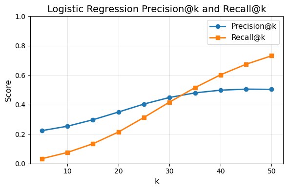

```python
def recall_at_k_logistic(y_true, y_score, users_test, k):
    user2labels = {}
    user2scores = {}

    for u, y, p in zip(users_test, y_true, y_score):
        user2labels.setdefault(u, []).append(y)
        user2scores.setdefault(u, []).append(p)

    recalls = []
    for u in user2labels:
        labels = np.array(user2labels[u])
        scores = np.array(user2scores[u])

        if labels.sum() == 0:
            continue

        topk_idx = scores.argsort()[::-1][:k]

        hits = labels[topk_idx].sum()
        total_positives = labels.sum()

        recalls.append(hits / total_positives)

    if len(recalls) == 0:
        return 0.0
    return np.mean(recalls)


def precision_at_k_logistic(y_true, y_score, users_test, k):
    user2labels = {}
    user2scores = {}

    for u, y, p in zip(users_test, y_true, y_score):
        user2labels.setdefault(u, []).append(y)
        user2scores.setdefault(u, []).append(p)

    precisions = []
    for u in user2labels:
        labels = np.array(user2labels[u])
        scores = np.array(user2scores[u])

        topk_idx = scores.argsort()[::-1][:k]

        hits = labels[topk_idx].sum()

        precisions.append(hits / k)

    if len(precisions) == 0:
        return 0.0
    return np.mean(precisions)


def compute_all_metrics_logistic(y_true, y_score, users_test):
    ks = list(range(5, 55, 5))
    recalls = []
    precisions = []
    for k in ks:
        r = recall_at_k_logistic(y_true, y_score, users_test, k)
        p = precision_at_k_logistic(y_true, y_score, users_test, k)
        recalls.append(r)
        precisions.append(p)
    return ks, recalls, precisions


from sklearn.metrics import accuracy_score, roc_auc_score

y_pred = clf.predict(X_test)
y_pred_proba = clf.predict_proba(X_test)[:, 1]

acc = accuracy_score(y_test, y_pred)
auc = roc_auc_score(y_test, y_pred_proba)

users_test = X_test_pairs[:, 0]

ks, recalls, precisions = compute_all_metrics_logistic(y_test, y_pred_proba, users_test)

recalls_a, precisions_a = recalls, precisions

print("Accuracy:", acc)
print("AUC:", auc)
for k, r, p in zip(ks, recalls, precisions):
    print(f"Precision@{k} = {p:.4f}  |  Recall@{k} = {r:.4f}")

plt.figure(figsize=(6,4))
plt.plot(ks, precisions, marker="o", label='Precision@k', linewidth=2)
plt.plot(ks, recalls, marker="s", label='Recall@k', linewidth=2)
plt.xlabel("k", fontsize=12)
plt.ylabel("Score", fontsize=12)
plt.title("Logistic Regression Precision@k and Recall@k", fontsize=14)
plt.ylim(0, 1)
plt.legend(fontsize=11)
plt.grid(True, alpha=0.3)
plt.tight_layout()
plt.show()
```

### **(B) BPR**

Here, we replicate Bayesian Personalized Ranking (BPR) from Pathak et al. (2017). BPR is trained in two stages. In the first stage, we train an item BPR to score items for users. For every user-item pair, BPR employs an item bias scalar, a $k$-dimension user vector and a $k$-dimension item vector to compute a score: $$\hat{x}_{u,i} = \beta_i + P_u \cdot Q_i$$ where $\beta_i$ is the item bias, $p_u$ and $q_i$ are $k$-dimensional latent parameter vectors for user $u$ and item $i$ respectively. We use stochastic gradient descent (SGD) to train the parameters on the $(u, i_p, i_n)$ triplets, with the goal to maximize: $$\sum_{(u, i_p, i_n) \in D} \log(\sigma(x_{u,i_p}(\theta) - x_{u,i_n}(\theta))) - \lambda ||\theta||^2$$ With the trained $\beta_i$, $p_u$ and $q_i$, we proceed to the second stage to train a bundle BPR. A bundle score is the average of individual item scores, adjusted with newly trained parameters: $k$-dimensional $\kappa$ on $\beta_i$, $k \times k$ adjustment matrices $\mu$ and $\omega$: $$\hat{x}_{u,b} = \frac{1}{|B_b|} \sum_{i \in B_b} \bigl[\kappa \beta_i + (\mu P_u)\cdot(\omega Q_i)\bigr]$$ They are optimized on the $(u, b_p, b_n)$ training triplet data with the same criterion: $$\sum_{(u, b_p, b_n) \in D} \log(\sigma(x_{u,b_p}(\theta) - x_{u,b_n}(\theta))) - \lambda ||\theta||^2$$

```python
# Recreate users_items_train properly
users_items_train = list(zip(item_sgd_users, sgd_pos_items, sgd_neg_items))

max_user_idx = max(u for u, _, _ in users_items_train) if users_items_train else 0
max_item_idx = max(max(i, j) for _, i, j in users_items_train) if users_items_train else 0

# Check the data dimensions
print(f"Number of users: {len(user_item_map_bpr)}")
print(f"Number of items: {len(items_set)}")
print(f"Max user index in users_items_train: {max_user_idx}")
print(f"Max item index in users_items_train: {max_item_idx}")
print(f"Number of training samples: {len(users_items_train)}")
```

```
Number of users: 71504
Number of items: 34239
Max user index in users_items_train: 88308
Max item index in users_items_train: 22465
Number of training samples: 5153210
```

```python
def item_bpr_sgd_model(users_items_train, num_users, num_items, k=10, max_iters=20, lr=0.01, reg=0.001):
    """
    BPR-based SGD for pairwise ranking optimization.

    Model: x_{u,i} = beta_i + u_factors · i_factors

    Objective: maximize sum log(sigmoid(x_{u,i_p} - x_{u,i_n})) - lambda ||theta||^2

    Parameters:
    - users_items_train: iterable of (u, i_pos, i_neg) tuples
    - k: latent dimension
    - lr: learning rate
    - reg: L2 regularization coefficient
    """
    rng = np.random.default_rng(42)

    # Initialize parameters
    user_factors = rng.normal(0, 0.01, size=(num_users, k))
    item_factors = rng.normal(0, 0.01, size=(num_items, k))
    beta_i = np.zeros(num_items, dtype=np.float64)

    # Convert to list if needed for multiple epochs
    train_list = list(users_items_train)
    n_train = len(train_list)

    for iteration in range(1, max_iters + 1):
        # Shuffle training data each epoch
        indices = rng.permutation(n_train)

        total_loss = 0.0
        for idx in indices:
            u_idx, i_pos_idx, i_neg_idx = train_list[idx]

            # Compute predictions for positive and negative items
            x_pos = beta_i[i_pos_idx] + np.dot(user_factors[u_idx], item_factors[i_pos_idx])
            x_neg = beta_i[i_neg_idx] + np.dot(user_factors[u_idx], item_factors[i_neg_idx])

            # Compute x_uij = x_{u,i_pos} - x_{u,i_neg}
            x_uij = x_pos - x_neg

            # Compute log(sigmoid(x_uij)) with numerical stability
            # log(sigmoid(x)) = -log(1 + exp(-x))
            # For stability: use -softplus(-x) where softplus(x) = log(1 + exp(x))
            if x_uij >= 0:
                loss_contribution = -np.log(1.0 + np.exp(-x_uij))
            else:
                # log(sigmoid(x)) = x - log(1 + exp(x)) when x < 0
                loss_contribution = x_uij - np.log(1.0 + np.exp(x_uij))

            # Gradient: d/dx_uij[log(sigmoid(x_uij))] = sigmoid(-x_uij) = 1 - sigmoid(x_uij)
            sigmoid_x = 1.0 / (1.0 + np.exp(-np.clip(x_uij, -100, 100)))  # Clip for stability

            total_loss += loss_contribution

            # Gradient of log(sigmoid(x_uij)) w.r.t x_uij is: 1 - sigmoid(x_uij)
            # This is the gradient multiplier for maximization
            gradient_multiplier = 1.0 - sigmoid_x

            # Update biases
            # d/d(beta_i_pos) = gradient_multiplier (since x_uij increases with beta_i_pos)
            # d/d(beta_i_neg) = -gradient_multiplier (since x_uij decreases with beta_i_neg)
            beta_i[i_pos_idx] += lr * (gradient_multiplier - reg * beta_i[i_pos_idx])
            beta_i[i_neg_idx] += lr * (-gradient_multiplier - reg * beta_i[i_neg_idx])

            # Update latent factors
            # d/d(p_u) = gradient_multiplier * (q_i_pos - q_i_neg)
            # d/d(q_i_pos) = gradient_multiplier * p_u
            # d/d(q_i_neg) = -gradient_multiplier * p_u
            p_u = user_factors[u_idx].copy()
            q_pos = item_factors[i_pos_idx].copy()
            q_neg = item_factors[i_neg_idx].copy()

            user_factors[u_idx] += lr * (gradient_multiplier * (q_pos - q_neg) - reg * p_u)
            item_factors[i_pos_idx] += lr * (gradient_multiplier * p_u - reg * q_pos)
            item_factors[i_neg_idx] += lr * (-gradient_multiplier * p_u - reg * q_neg)

        # Compute regularization loss
        reg_loss = reg * (np.sum(user_factors**2) + np.sum(item_factors**2) + np.sum(beta_i**2))
        total_loss -= reg_loss

        if iteration % 1 == 0:
            print(f"BPR-SGD Iteration {iteration}")
            print(f"  Total Loss (approx) = {total_loss:.6f}")
            print(f"  Avg Loss per sample = {total_loss / n_train:.6f}")

    return beta_i, user_factors, item_factors
```

```python
# Train BPR model on items
# Use the actual max indices from the data, not the count of non-empty entries
print(f"Training BPR with:")
print(f"  num_users = {max_user_idx + 1} (max user idx: {max_user_idx})")
print(f"  num_items = {max_item_idx + 1} (max item idx: {max_item_idx})")

beta_i, user_factors, item_factors = item_bpr_sgd_model(
    users_items_train,
    num_users=max_user_idx + 1,
    num_items=max_item_idx + 1,
    k=20,
    max_iters=20,
    lr=0.1,
    reg=0.001
)
```

```
Training BPR with:
  num_users = 88309 (max user idx: 88308)
  num_items = 22466 (max item idx: 22465)
BPR-SGD Iteration 1
  Total Loss (approx) = -3113138.433507
  Avg Loss per sample = -0.604116
BPR-SGD Iteration 2
  Total Loss (approx) = -2416300.475250
  Avg Loss per sample = -0.468892
BPR-SGD Iteration 3
  Total Loss (approx) = -2180949.757322
  Avg Loss per sample = -0.423222
BPR-SGD Iteration 4
  Total Loss (approx) = -2088858.571224
  Avg Loss per sample = -0.405351
BPR-SGD Iteration 5
  Total Loss (approx) = -2038714.824016
  Avg Loss per sample = -0.395620
BPR-SGD Iteration 6
  Total Loss (approx) = -2007380.820264
  Avg Loss per sample = -0.389540
BPR-SGD Iteration 7
  Total Loss (approx) = -1985372.822513
  Avg Loss per sample = -0.385269
BPR-SGD Iteration 8
  Total Loss (approx) = -1969470.793037
  Avg Loss per sample = -0.382183
BPR-SGD Iteration 9
  Total Loss (approx) = -1956113.253692
  Avg Loss per sample = -0.379591
BPR-SGD Iteration 10
  Total Loss (approx) = -1946581.232163
  Avg Loss per sample = -0.377741
BPR-SGD Iteration 11
  Total Loss (approx) = -1938029.067879
  Avg Loss per sample = -0.376082
BPR-SGD Iteration 12
  Total Loss (approx) = -1931155.850089
  Avg Loss per sample = -0.374748
BPR-SGD Iteration 13
```

[output cut: 8 more lines]

```
BPR-SGD Iteration 16
  Total Loss (approx) = -1912406.502210
  Avg Loss per sample = -0.371110
BPR-SGD Iteration 17
  Total Loss (approx) = -1909711.592743
  Avg Loss per sample = -0.370587
BPR-SGD Iteration 18
  Total Loss (approx) = -1905722.128117
  Avg Loss per sample = -0.369813
BPR-SGD Iteration 19
  Total Loss (approx) = -1903774.851145
  Avg Loss per sample = -0.369435
BPR-SGD Iteration 20
  Total Loss (approx) = -1901353.855009
  Avg Loss per sample = -0.368965
```

```python
def bundle_bpr_sgd_model(users_bundles_train, bundle_item_map, beta_i, user_factors, item_factors,
                         num_users, num_bundles, k=10, max_iters=10, lr=0.01, reg=0.001):
    """
    Bundle BPR-SGD using pre-trained item embeddings.

    Model: x_{u,b} = (1/|B_b|) * sum_{i in B_b} [kappa · beta_i + (mu · p_u) · (omega · q_i)]

    Where:
    - kappa: k-dimensional weight vector for item biases
    - mu: k * k transformation matrix for user factors
    - omega: k * k transformation matrix for item factors

    Parameters:
    - users_bundles_train: list of (user_idx, bundle_pos_idx, bundle_neg_idx) tuples
    - bundle_item_map: dict mapping bundle_idx -> set of item indices
    - beta_i, user_factors, item_factors: pre-trained from item BPR
    - k: latent dimension (must match item_factors dimension)
    - max_iters, lr, reg: training hyperparameters
    """
    rng = np.random.default_rng(42)

    # Initialize transformation parameters
    kappa = rng.normal(0, 0.01, size=k)
    mu = rng.normal(0, 0.01, size=(k, k))
    omega = rng.normal(0, 0.01, size=(k, k))

    train_list = list(users_bundles_train)
    n_train = len(train_list)

    def predict_bundle_score(u_idx, b_idx):
        """Compute bundle score for user u and bundle b."""
        items_in_bundle = bundle_item_map.get(b_idx, set())
        if not items_in_bundle:
            return 0.0

        p_u = user_factors[u_idx]  # k-dimensional
        mu_pu = np.dot(mu, p_u)    # k-dimensional: mu · p_u

        total_score = 0.0
        for i_idx in items_in_bundle:
            q_i = item_factors[i_idx]          # k-dimensional
            omega_qi = np.dot(omega, q_i)      # k-dimensional: omega · q_i

            # Item contribution: kappa · beta_i + (mu · p_u) · (omega · q_i)
            item_score = np.dot(kappa, beta_i[i_idx] * np.ones(k)) + np.dot(mu_pu, omega_qi)
            total_score += item_score

        # Average over bundle items
        return total_score / len(items_in_bundle)

    for iteration in range(1, max_iters + 1):
        indices = rng.permutation(n_train)
        total_loss = 0.0

        for idx in indices:
            u_idx, b_pos_idx, b_neg_idx = train_list[idx]

            # Compute bundle scores
            x_pos = predict_bundle_score(u_idx, b_pos_idx)
            x_neg = predict_bundle_score(u_idx, b_neg_idx)
            x_uij = x_pos - x_neg

            # Compute loss contribution (numerically stable)
            if x_uij >= 0:
                loss_contribution = -np.log(1.0 + np.exp(-x_uij))
            else:
                loss_contribution = x_uij - np.log(1.0 + np.exp(x_uij))

            total_loss += loss_contribution

            # Gradient multiplier
            sigmoid_x = 1.0 / (1.0 + np.exp(-np.clip(x_uij, -100, 100)))
            grad_mult = 1.0 - sigmoid_x

            # Get bundle items
            items_pos = bundle_item_map.get(b_pos_idx, set())
            items_neg = bundle_item_map.get(b_neg_idx, set())

            if not items_pos or not items_neg:
                continue

            n_pos = len(items_pos)
            n_neg = len(items_neg)

            # Pre-compute user transformations
            p_u = user_factors[u_idx]
            mu_pu = np.dot(mu, p_u)

            # Initialize gradients
            grad_kappa = np.zeros(k)
            grad_mu = np.zeros((k, k))
            grad_omega = np.zeros((k, k))

            # Gradient from positive bundle (increase score)
            for i_idx in items_pos:
                q_i = item_factors[i_idx]
                omega_qi = np.dot(omega, q_i)

                # d/d(kappa): beta_i / |B_pos|
                grad_kappa += (grad_mult / n_pos) * beta_i[i_idx] * np.ones(k)

                # d/d(mu): outer product of result with p_u, scaled by omega_qi
                # (mu·p_u)·(omega·q_i) differentiates to: (omega·q_i) ⊗ p_u
                grad_mu += (grad_mult / n_pos) * np.outer(omega_qi, p_u)

                # d/d(omega): outer product with q_i, scaled by mu_pu
                # (mu·p_u)·(omega·q_i) differentiates to: (mu·p_u) ⊗ q_i
                grad_omega += (grad_mult / n_pos) * np.outer(mu_pu, q_i)

            # Gradient from negative bundle (decrease score)
            for i_idx in items_neg:
                q_i = item_factors[i_idx]
                omega_qi = np.dot(omega, q_i)

                grad_kappa -= (grad_mult / n_neg) * beta_i[i_idx] * np.ones(k)
                grad_mu -= (grad_mult / n_neg) * np.outer(omega_qi, p_u)
                grad_omega -= (grad_mult / n_neg) * np.outer(mu_pu, q_i)

            # Update parameters with regularization
            kappa += lr * (grad_kappa - reg * kappa)
            mu += lr * (grad_mu - reg * mu)
            omega += lr * (grad_omega - reg * omega)

        # Compute regularization loss
        reg_loss = reg * (np.sum(kappa**2) + np.sum(mu**2) + np.sum(omega**2))
        total_loss -= reg_loss

        if iteration % 1 == 0:
            print(f"Bundle BPR-SGD Iteration {iteration}")
            print(f"  Total Loss = {total_loss:.6f}")
            print(f"  Avg Loss per sample = {total_loss / n_train:.6f}")

    return kappa, mu, omega
```

```python
# Create bundle training data from graph_sampling output
sgd_users, sgd_pos_bundles, sgd_neg_bundles = graph_sampling(
    len(training_data_bpr)*30, training_data_bpr, user_bundle_map_train_bpr
)
users_bundles_train = list(zip(sgd_users, sgd_pos_bundles, sgd_neg_bundles))

print(f"Training Bundle BPR with:")
print(f"  Number of users = {len(user_factors)}")
print(f"  Number of bundles: {len(bundle_item_map)}")
print(f"  Number of training samples: {len(users_bundles_train)}")
print(f"  Latent dimension k: {user_factors.shape[1]}")

# Train bundle BPR model
kappa, mu, omega = bundle_bpr_sgd_model(
    users_bundles_train,
    bundle_item_map,
    beta_i,
    user_factors,
    item_factors,
    num_users=len(user_factors),
    num_bundles=len(bundle_item_map),
    k=user_factors.shape[1],  # Use same k as item model
    max_iters=10,
    lr=0.005,
    reg=0.001
)

print("\nBundle model training complete!")
print(f"Learned parameters: kappa shape={kappa.shape}, mu shape={mu.shape}, omega shape={omega.shape}")
```

```
0
100000
200000
300000
400000
500000
600000
700000
800000
900000
1000000
1100000
1200000
Training Bundle BPR with:
  Number of users = 88309
  Number of bundles: 615
  Number of training samples: 2460480
  Latent dimension k: 20
Bundle BPR-SGD Iteration 1
  Total Loss = -1146916.496249
  Avg Loss per sample = -0.466135
Bundle BPR-SGD Iteration 2
  Total Loss = -1144685.812347
  Avg Loss per sample = -0.465229
Bundle BPR-SGD Iteration 3
  Total Loss = -1144329.729210
  Avg Loss per sample = -0.465084
Bundle BPR-SGD Iteration 4
  Total Loss = -1144444.603841
  Avg Loss per sample = -0.465131
Bundle BPR-SGD Iteration 5
  Total Loss = -1144636.662801
  Avg Loss per sample = -0.465209
Bundle BPR-SGD Iteration 6
  Total Loss = -1144492.881942
  Avg Loss per sample = -0.465150
Bundle BPR-SGD Iteration 7
  Total Loss = -1144278.025017
  Avg Loss per sample = -0.465063
Bundle BPR-SGD Iteration 8
  Total Loss = -1144522.873954
  Avg Loss per sample = -0.465162
Bundle BPR-SGD Iteration 9
  Total Loss = -1144508.446671
  Avg Loss per sample = -0.465157
Bundle BPR-SGD Iteration 10
  Total Loss = -1144687.045205
  Avg Loss per sample = -0.465229

Bundle model training complete!
Learned parameters: kappa shape=(20,), mu shape=(20, 20), omega shape=(20, 20)
```

```python
def predict_bundle_score(u_idx, b_idx, kappa, mu, omega, beta_i, user_factors, item_factors, bundle_item_map):
    """
    Compute bundle score for user u and bundle b using learned transformation parameters.
    """
    items_in_bundle = bundle_item_map.get(b_idx, set())
    if not items_in_bundle:
        return 0.0

    p_u = user_factors[u_idx]  # k-dimensional
    mu_pu = np.dot(mu, p_u)    # k-dimensional: mu · p_u

    total_score = 0.0
    for i_idx in items_in_bundle:
        q_i = item_factors[i_idx]          # k-dimensional
        omega_qi = np.dot(omega, q_i)      # k-dimensional: omega · q_i

        # Item contribution: kappa · beta_i + (mu · p_u) · (omega · q_i)
        k = len(kappa)
        item_score = np.dot(kappa, beta_i[i_idx] * np.ones(k)) + np.dot(mu_pu, omega_qi)
        total_score += item_score

    # Average over bundle items
    return total_score / len(items_in_bundle)
```

```python
sgd_users_test_bpr, sgd_pos_bundles_test_bpr, sgd_neg_bundles_test_bpr = graph_sampling(
    len(test_data_bpr)*30, test_data_bpr, user_bundle_map_bpr
)

X_test_pairs_bpr = []
y_test_bpr = []

for u, b_pos, b_neg in zip(sgd_users_test_bpr, sgd_pos_bundles_test_bpr, sgd_neg_bundles_test_bpr):
    X_test_pairs_bpr.append([u, b_pos])
    y_test_bpr.append(1)
    X_test_pairs_bpr.append([u, b_neg])
    y_test_bpr.append(0)

print(f"Total test samples for BPR evaluation: {len(X_test_pairs_bpr)}")
```

```
0
100000
200000
300000
Total test samples for BPR evaluation: 1230240
```

```python
# Evaluate Bundle BPR Model using predict_bundle_score
print("="*60)
print("Evaluating Bundle BPR Model on Test Data")
print("="*60)

# Use X_test_pairs_bpr and y_test_bpr from cell 38
print(f"Total test samples: {len(X_test_pairs_bpr)}")

# Compute scores for all test pairs
y_pred_scores = []
for user_idx, bundle_idx in X_test_pairs_bpr:
    score = predict_bundle_score(
        user_idx,
        bundle_idx,
        kappa,
        mu,
        omega,
        beta_i,
        user_factors,
        item_factors,
        bundle_item_map_bpr
    )
    y_pred_scores.append(score)

y_pred_scores = np.array(y_pred_scores)
y_test_bpr = np.array(y_test_bpr)

from sklearn.metrics import roc_auc_score, accuracy_score

auc = roc_auc_score(y_test_bpr, y_pred_scores)
print(f"\nBundle BPR AUC: {auc:.4f}")

y_pred_binary = []
i = 0
for i in range(len(y_pred_scores)):
    if i % 2 == 1:
        if y_pred_scores[i - 1] > y_pred_scores[i]:
            y_pred_binary.append(1)
            y_pred_binary.append(0)
        else:
            y_pred_binary.append(0)
            y_pred_binary.append(1)

accuracy = accuracy_score(y_test_bpr, y_pred_binary)
print(f"Bundle BPR Accuracy: {accuracy:.4f}")

# Calculate Recall@K and Precision@K metrics
# Group test data by user
user_bundle_scores = defaultdict(list)  # user -> [(bundle, score, label)]
for (user_idx, bundle_idx), score, label in zip(X_test_pairs_bpr, y_pred_scores, y_test_bpr):
    user_bundle_scores[user_idx].append((bundle_idx, score, label))

# Compute Recall@K and Precision@K for each user
recall_metrics = {}
precision_metrics = {}
for k in range(5, 55, 5):
    recalls = []
    precisions = []
    for user_idx, bundle_data in user_bundle_scores.items():
        # Sort by score (descending)
        sorted_bundles = sorted(bundle_data, key=lambda x: x[1], reverse=True)

        # Get top-K bundles
        top_k = sorted_bundles[:k]

        # Count positives in top-K
        positive_in_topk = sum(1 for _, _, label in top_k if label == 1)

        # Count total positives for this user
        total_positives = sum(1 for _, _, label in bundle_data if label == 1)

        # Calculate Precision@K: positive_in_topk / k
        precision = positive_in_topk / k
        precisions.append(precision)

        # Calculate Recall@K: positive_in_topk / total_positives
        recall = positive_in_topk / total_positives
        recalls.append(recall)

    precision_metrics[f'Precision@{k}'] = np.mean(precisions) if precisions else 0.0
    recall_metrics[f'Recall@{k}'] = np.mean(recalls) if recalls else 0.0
    print(f"  Precision@{k}: {precision_metrics[f'Precision@{k}']:.4f}  |  Recall@{k}: {recall_metrics[f'Recall@{k}']:.4f}")

print("="*60)
```

```
============================================================
Evaluating Bundle BPR Model on Test Data
============================================================
Total test samples: 1230240

Bundle BPR AUC: 0.7597
Bundle BPR Accuracy: 0.7966
  Precision@5: 0.5411  |  Recall@5: 0.0803
  Precision@10: 0.6204  |  Recall@10: 0.1867
  Precision@15: 0.6767  |  Recall@15: 0.3076
  Precision@20: 0.7151  |  Recall@20: 0.4320
  Precision@25: 0.7325  |  Recall@25: 0.5458
  Precision@30: 0.7299  |  Recall@30: 0.6402
  Precision@35: 0.7132  |  Recall@35: 0.7145
  Precision@40: 0.6882  |  Recall@40: 0.7719
  Precision@45: 0.6593  |  Recall@45: 0.8164
  Precision@50: 0.6291  |  Recall@50: 0.8509
============================================================
```

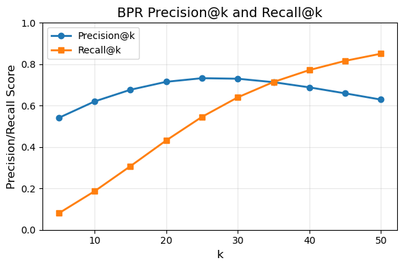

```python
ks = list(range(5, 55, 5))

precisions = [precision_metrics[rk] for rk in precision_metrics]
recalls = [recall_metrics[rk] for rk in recall_metrics]

precisions_b, recalls_b = precisions, recalls

plt.figure(figsize=(6,4))
plt.plot(ks, precisions, marker='o', label='Precision@k', linewidth=2)
plt.plot(ks, recalls, marker='s', label='Recall@k', linewidth=2)
plt.xlabel("k", fontsize=12)
plt.ylabel("Precision/Recall Score", fontsize=12)
plt.title("BPR Precision@k and Recall@k", fontsize=14)
plt.ylim(0, 1)
plt.legend(fontsize=10)
plt.grid(True, alpha=0.3)
plt.tight_layout()
plt.show()
```

### **(C) Latent Factor Model**

#### Dataset Wrapper

We wrap $(u,b,label)$ triples into a simple PyTorch `Dataset`, which enables efficient mini-batch training using Dataloader.

```python
import torch
import torch.nn as nn
import torch.optim as optim
from torch.utils.data import Dataset, DataLoader
from sklearn.metrics import accuracy_score, roc_auc_score
```

```python
class PairDataset(Dataset):
    def __init__(self, pairs, labels):
        self.users = torch.LongTensor(pairs[:, 0])
        self.bundles = torch.LongTensor(pairs[:, 1])
        self.labels = torch.FloatTensor(labels)

    def __len__(self):
        return len(self.labels)

    def __getitem__(self, idx):
        return self.users[idx], self.bundles[idx], self.labels[idx]


class MF(nn.Module):
    def __init__(self, num_users, num_bundles, emb_dim=32):
        super().__init__()
        self.user_emb = nn.Embedding(num_users, emb_dim)
        self.bundle_emb = nn.Embedding(num_bundles, emb_dim)

        self.user_bias = nn.Embedding(num_users, 1)
        self.bundle_bias = nn.Embedding(num_bundles, 1)
        self.global_bias = nn.Parameter(torch.zeros(1))

        nn.init.normal_(self.user_emb.weight, std=0.01)
        nn.init.normal_(self.bundle_emb.weight, std=0.01)
        nn.init.zeros_(self.user_bias.weight)
        nn.init.zeros_(self.bundle_bias.weight)

    def forward(self, user_ids, bundle_ids):
        u = self.user_emb(user_ids)
        b = self.bundle_emb(bundle_ids)
        dot = (u * b).sum(dim=1, keepdim=True)
        u_bias = self.user_bias(user_ids)
        b_bias = self.bundle_bias(bundle_ids)

        logits = dot + u_bias + b_bias + self.global_bias
        return logits.squeeze(1)
```

#### 1. Latent Representation

For each user $u$ and bundle $b$:

- **User embedding**: $$ p_u \in \mathbb{R}^d $$
- **Bundle embedding**: $$ q_b \in \mathbb{R}^d $$

The dimensionality $d$ controls model capacity.

#### 2. MF Scoring Function

The predicted score is the inner product of latent factors:

$$ \hat{y}_{u,b} = p_u^\top q_b $$

This models the similarity of user preferences and bundle characteristics. But the full version additionally includes **bias terms** for better calibration.

##### With Bias Terms

We include:

- **User bias:** $b_u$
- **Bundle bias:** $b_b$
- **Global bias:** $b_0$

Thus the full scoring function becomes:

$$ s(u,b) = p_u^\top q_b + b_u + b_b + b_0 $$

This structure captures:

- **global attractiveness** of bundles (e.g., very popular ones),
- **user activeness** (some users interact with many bundles),
- but keeps **personal preference** in the latent vectors (p_u, q_b).

```python
emb_dim    = 1
batch_size = 2048
lr         = 5e-3
n_epochs   = 6
device     = torch.device("cuda" if torch.cuda.is_available() else "cpu")

train_dataset = PairDataset(X_train_pairs, y_train)
test_dataset  = PairDataset(X_test_pairs, y_test)

train_loader = DataLoader(train_dataset, batch_size=batch_size, shuffle=True)
test_loader  = DataLoader(test_dataset, batch_size=batch_size, shuffle=False)

model = MF(num_users=num_users, num_bundles=num_bundles, emb_dim=emb_dim).to(device)
criterion = nn.BCEWithLogitsLoss()
optimizer = optim.Adam(model.parameters(), lr=lr)
```

#### 3. Logistic Output Layer

For binary interaction prediction (positive/negative), we apply the sigmoid function to convert raw scores into probabilities:

$$ \hat{p}_{u,b} = \sigma(s(u,b)) = \frac{1}{1 + e^{-s(u,b)}} $$

This allows the use of **binary cross-entropy loss (BCE)**.

#### 4. Training Objective (Binary Cross-Entropy)

For each user–bundle pair $(u, b)$ with label $y_{u,b} \in \{0,1\}$:

$$ \mathrm{L} = -\left[y_{u,b} \log \hat{p}_{u,b} + (1 - y_{u,b}) \log(1 - \hat{p}_{u,b})\right] $$

MF parameters $\theta = \{p_u, q_b, b_u, b_b, b_0\}$ are updated by minimizing total loss:

$$ \mathrm{J}(\theta) = \sum_{(u,b)} \mathrm{L}_{u,b} $$

In PyTorch:

```
criterion = nn.BCEWithLogitsLoss()
```

This automatically combines sigmoid + BCE.

#### 5. Forward Pass (Detailed Formula Breakdown)

##### Explanation by Formula

1. **Latent vectors:**

$$ u = p_u,\qquad b = q_b $$

2. **Inner product:**

$$ \text{dot}(u,b) = \sum_{i=1}^{d} p_{u,i} q_{b,i} $$

3. **Add biases:**

$$ \text{logit}(u,b) = p_u^\top q_b + b_u + b_b + b_0 $$

4. **Returned logits** go into BCE for probability estimation.

#### 6. Training Loop (Detailed Explanation)

##### Gradient Update

$$ \theta \leftarrow \theta - \eta \, \frac{\partial \mathrm{J}}{\partial \theta} $$

#### 7. Why MF Fits This Task Better

##### ✔ Learns latent structure from graph-sampled hard negatives

Graph sampling produces:

- positives from true interactions
- negatives drawn from **other users’ positives**, forming strong hard negatives

These negatives often have:

- similar popularity
- similar bundle size
- similar item coverage

MF is well-equipped to distinguish such subtle differences by learning latent user–bundle compatibility through:

$$p_u^T q_b$$

Where logistic regression collapses to popularity statistics, MF captures deeper preference structure.

##### ✔ Embeddings generalize to unseen user–bundle combinations

MF naturally generalizes to pairs never seen during training.

If both embeddings $p_u$ and $q_b$ were shaped by other interactions, MF can still estimate, which allows MF to handle sparse or unseen combinations without requiring explicit side features.

##### ✔ Clean, efficient, and easy to extend

MF offers a **clean and efficient solution** to the recommendation problem.

The entire model consists of two embedding tables and a dot product:

$$\text{score}(u, b) = p_u^T q_b + \text{biases}$$

This simplicity gives MF several meta-advantages:

- fast training and inference
- minimal memory footprint
- low engineering overhead
- easy extension to advanced models such as **NeuMF**, **LightGCN**, or **BPR-MF**

#### 8. Limitations of MF

Although MF works well for this dataset, several important limitations remain:

##### ❗MF optimizes classification, not ranking

In this implementation MF uses BCE loss, which trains the model as a **binary classifier**. This means MF does **not explicitly encourage** positive bundles to rank above negatives. As a result, MF may underperform on ranking metrics (like Recall@K) compared to methods such as BPR that directly optimize relative ordering.

##### ❗Dot-product restricts the model expressive ability

MF models compatibility using a simple linear interaction:

$$s(u, b) = p_u^\top q_b$$

This imposes a **linear compatibility function** between user and bundle. Consequently, MF cannot capture:

- complex feature interactions
- higher-order patterns
- non-linear user preferences

This expressiveness limitation makes MF less flexible than neural recommenders such as NeuMF or DeepFM.

```python
def recall_at_k_logistic(y_true, y_score, users_test, k):
    user2labels = {}
    user2scores = {}

    for u, y, p in zip(users_test, y_true, y_score):
        user2labels.setdefault(u, []).append(y)
        user2scores.setdefault(u, []).append(p)

    recalls = []
    for u in user2labels:
        labels = np.array(user2labels[u])
        scores = np.array(user2scores[u])

        if labels.sum() == 0:
            continue

        topk_idx = scores.argsort()[::-1][:k]

        hits = labels[topk_idx].sum()
        total_positives = labels.sum()

        recalls.append(hits / total_positives)
    if len(recalls) == 0:
        return 0.0
    return np.mean(recalls)


def precision_at_k_logistic(y_true, y_score, users_test, k):
    user2labels = {}
    user2scores = {}

    for u, y, p in zip(users_test, y_true, y_score):
        user2labels.setdefault(u, []).append(y)
        user2scores.setdefault(u, []).append(p)

    precisions = []
    for u in user2labels:
        labels = np.array(user2labels[u])
        scores = np.array(user2scores[u])

        topk_idx = scores.argsort()[::-1][:k]

        hits = labels[topk_idx].sum()

        precisions.append(hits / k)

    if len(precisions) == 0:
        return 0.0
    return np.mean(precisions)
```

```python
def recall_at_k(all_labels, all_probs, all_users, k):
    user2labels = {}
    user2scores = {}

    for u, y, p in zip(all_users, all_labels, all_probs):
        user2labels.setdefault(u, []).append(y)
        user2scores.setdefault(u, []).append(p)

    recalls = []
    for u in user2labels:
        labels = np.array(user2labels[u])
        scores = np.array(user2scores[u])

        if labels.sum() == 0:
            continue

        topk_idx = scores.argsort()[::-1][:k]

        hits = labels[topk_idx].sum()
        total_positives = labels.sum()

        recalls.append(hits / total_positives)

    return np.mean(recalls)

def precision_at_k(all_labels, all_probs, all_users, k):
    user2labels = {}
    user2scores = {}

    for u, y, p in zip(all_users, all_labels, all_probs):
        user2labels.setdefault(u, []).append(y)
        user2scores.setdefault(u, []).append(p)

    precisions = []
    for u in user2labels:
        labels = np.array(user2labels[u])
        scores = np.array(user2scores[u])

        topk_idx = scores.argsort()[::-1][:k]

        hits = labels[topk_idx].sum()

        precisions.append(hits / k)

    return np.mean(precisions)

def evaluate(loader):
    model.eval()
    all_labels = []
    all_probs  = []
    all_users  = []

    with torch.no_grad():
        for users, bundles, labels in loader:
            users   = users.to(device)
            bundles = bundles.to(device)
            labels  = labels.to(device)

            logits = model(users, bundles)
            probs  = torch.sigmoid(logits)

            all_labels.append(labels.cpu())
            all_probs.append(probs.cpu())
            all_users.append(users.cpu())

    all_labels = torch.cat(all_labels).numpy()
    all_probs  = torch.cat(all_probs).numpy()
    all_users  = torch.cat(all_users).numpy()

    preds = (all_probs >= 0.5).astype("int32")

    acc = accuracy_score(all_labels, preds)
    auc = roc_auc_score(all_labels, all_probs)

    recalls = [
        recall_at_k(all_labels, all_probs, all_users, k)
        for k in range(5, 55, 5)
    ]

    precisions = [
        precision_at_k(all_labels, all_probs, all_users, k)
        for k in range(5, 55, 5)
    ]

    return acc, auc, recalls, precisions
```

```python
best_auc = 0
best_recalls = None
best_precisions = None

for epoch in range(1, n_epochs + 1):
    model.train()
    total_loss = 0.0

    for users, bundles, labels in train_loader:
        users   = users.to(device)
        bundles = bundles.to(device)
        labels  = labels.to(device)

        optimizer.zero_grad()
        logits = model(users, bundles)
        loss   = criterion(logits, labels)
        loss.backward()
        optimizer.step()

        total_loss += loss.item() * labels.size(0)

    avg_loss = total_loss / len(train_dataset)

    train_acc, train_auc, train_recalls, train_precisions = evaluate(train_loader)
    test_acc,  test_auc,  test_recalls, test_precisions  = evaluate(test_loader)

    print(f"\nEpoch {epoch:02d}")
    print(f"  Loss={avg_loss:.4f}")
    print(f"  Train: acc={train_acc:.4f}, auc={train_auc:.4f}, recalls={train_recalls}, precisions={train_precisions}")
    print(f"  Test : acc={test_acc:.4f},  auc={test_auc:.4f},  recalls={test_recalls}, precisions={test_precisions}")

    # Track best model by AUC
    if test_auc > best_auc:
        best_auc = test_auc
        best_recalls = test_recalls
        best_precisions = test_precisions
        torch.save(model.state_dict(), "best_model.pt")
        print("  --> Best model updated!")
```

```
Epoch 01
  Loss=0.5108
  Train: acc=0.7706, auc=0.8559, recalls=[np.float32(0.078059286), np.float32(0.16315883), np.float32(0.2539071), np.float32(0.345157), np.float32(0.42511153), np.float32(0.48548785), np.float32(0.53159916), np.float32(0.5719933), np.float32(0.61001366), np.float32(0.64597064)], precisions=[np.float…
  Test : acc=0.6902,  auc=0.7969,  recalls=[np.float32(0.07265325), np.float32(0.1688154), np.float32(0.2881473), np.float32(0.41504326), np.float32(0.5331885), np.float32(0.6301138), np.float32(0.7036023), np.float32(0.75740033), np.float32(0.79770076), np.float32(0.83002925)], precisions=[np.float…
  --> Best model updated!

Epoch 02
  Loss=0.4514
  Train: acc=0.7953, auc=0.8717, recalls=[np.float32(0.08331183), np.float32(0.17079644), np.float32(0.26289308), np.float32(0.3552761), np.float32(0.4360407), np.float32(0.496583), np.float32(0.5422416), np.float32(0.58213484), np.float32(0.6199147), np.float32(0.6558223)], precisions=[np.float32(0…
  Test : acc=0.6946,  auc=0.7962,  recalls=[np.float32(0.07188316), np.float32(0.16689532), np.float32(0.2855035), np.float32(0.41221452), np.float32(0.5314119), np.float32(0.62994176), np.float32(0.70459723), np.float32(0.7595012), np.float32(0.80012435), np.float32(0.83221924)], precisions=[np.flo…

Epoch 03
  Loss=0.4362
  Train: acc=0.8041, auc=0.8795, recalls=[np.float32(0.08364911), np.float32(0.17223011), np.float32(0.26539254), np.float32(0.35841405), np.float32(0.43961158), np.float32(0.5011009), np.float32(0.5478876), np.float32(0.5884526), np.float32(0.6262646), np.float32(0.6617527)], precisions=[np.float32…
  Test : acc=0.6869,  auc=0.7924,  recalls=[np.float32(0.07022157), np.float32(0.16210225), np.float32(0.2784268), np.float32(0.40527883), np.float32(0.52635485), np.float32(0.62774867), np.float32(0.7046), np.float32(0.76039433), np.float32(0.80088514), np.float32(0.8324643)], precisions=[np.float3…

Epoch 04
  Loss=0.4263
  Train: acc=0.8070, auc=0.8835, recalls=[np.float32(0.08352635), np.float32(0.17261948), np.float32(0.26629674), np.float32(0.35964862), np.float32(0.4412467), np.float32(0.50321746), np.float32(0.55051905), np.float32(0.5912222), np.float32(0.62883013), np.float32(0.6639278)], precisions=[np.float…
  Test : acc=0.6860,  auc=0.7898,  recalls=[np.float32(0.070290804), np.float32(0.16178869), np.float32(0.27828008), np.float32(0.4050605), np.float32(0.5262111), np.float32(0.62814045), np.float32(0.70546347), np.float32(0.7612651), np.float32(0.8016062), np.float32(0.83283687)], precisions=[np.flo…

Epoch 05
  Loss=0.4193
  Train: acc=0.8091, auc=0.8875, recalls=[np.float32(0.083075635), np.float32(0.17174216), np.float32(0.26565892), np.float32(0.35922554), np.float32(0.44091582), np.float32(0.5027391), np.float32(0.5496712), np.float32(0.59032845), np.float32(0.62830883), np.float32(0.6638647)], precisions=[np.floa…
  Test : acc=0.6848,  auc=0.7872,  recalls=[np.float32(0.06953984), np.float32(0.15829632), np.float32(0.27089992), np.float32(0.39700037), np.float32(0.5189989), np.float32(0.6225809), np.float32(0.7023296), np.float32(0.76022667), np.float32(0.8016966), np.float32(0.8333633)], precisions=[np.float…

Epoch 06
  Loss=0.4142
  Train: acc=0.8115, auc=0.8907, recalls=[np.float32(0.082801275), np.float32(0.17142121), np.float32(0.2655193), np.float32(0.3589747), np.float32(0.44053015), np.float32(0.5023245), np.float32(0.54923683), np.float32(0.5899927), np.float32(0.6282163), np.float32(0.66416633)], precisions=[np.float3…
  Test : acc=0.6842,  auc=0.7843,  recalls=[np.float32(0.0690656), np.float32(0.15705554), np.float32(0.26873553), np.float32(0.39487547), np.float32(0.5173676), np.float32(0.62160283), np.float32(0.7017869), np.float32(0.75996685), np.float32(0.80152494), np.float32(0.8330376)], precisions=[np.floa…
```

```
Best Model Accuracy: 0.6901718363896475
Best Model AUC: 0.7969261510393812

Best Model Recalls:
  Recall@5: 0.0727
  Recall@10: 0.1688
  Recall@15: 0.2881
  Recall@20: 0.4150
  Recall@25: 0.5332
  Recall@30: 0.6301
  Recall@35: 0.7036
  Recall@40: 0.7574
  Recall@45: 0.7977
  Recall@50: 0.8300

Best Model Precisions:
  Precision@5: 0.5121
  Precision@10: 0.5720
  Precision@15: 0.6347
  Precision@20: 0.6810
  Precision@25: 0.7042
  Precision@30: 0.7043
  Precision@35: 0.6876
  Precision@40: 0.6614
  Precision@45: 0.6317
  Precision@50: 0.6027
```

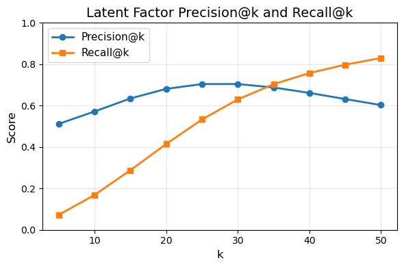

```python
# Load best model
model.load_state_dict(torch.load("best_model.pt"))

# Evaluate again
acc, auc, best_recalls, best_precisions = evaluate(test_loader)
ks = list(range(5, 55, 5))

precisions_c, recalls_c = best_precisions, best_recalls

print("Best Model Accuracy:", acc)
print("Best Model AUC:", auc)

print("\nBest Model Recalls:")
for k, r in zip(ks, best_recalls):
    print(f"  Recall@{k}: {r:.4f}")

print("\nBest Model Precisions:")
for k, r in zip(ks, best_precisions):
    print(f"  Precision@{k}: {r:.4f}")

plt.figure(figsize=(6,4))
plt.plot(ks, best_precisions, marker="o", label='Precision@k', linewidth=2)
plt.plot(ks, best_recalls, marker="s", label='Recall@k', linewidth=2)
plt.xlabel("k", fontsize=12)
plt.ylabel("Score", fontsize=12)
plt.title("Latent Factor Precision@k and Recall@k", fontsize=14)
plt.ylim(0, 1)
plt.legend(fontsize=11)
plt.grid(True, alpha=0.3)
plt.tight_layout()
plt.show()
```

### (D) BundleRecNet: Neural Collaborative Filtering for Bundle Recommendation

**BundleRecNet** is a deep learning model designed to predict user-bundle affinity scores for personalized bundle recommendations. The model combines two complementary approaches inspired by Neural Collaborative Filtering (NCF):

#### Architecture Overview

1. **Dual Embedding System**: The model learns separate embeddings for users and items in two different spaces:
   - **GMF (Generalized Matrix Factorization) path**: Captures linear interactions through element-wise product
   - **MLP (Multi-Layer Perceptron) path**: Captures non-linear interactions through deep neural networks
2. **Bundle Representation**: Since bundles are collections of items, the model uses an **attention mechanism** to aggregate item embeddings into bundle representations:
   - Each bundle's items are embedded individually
   - An attention network learns which items are most important for the bundle representation
   - The weighted sum of item embeddings forms the bundle embedding
3. **Prediction**: The final affinity score combines:
   - GMF interaction: `user_emb ⊙ bundle_emb` (element-wise product)
   - MLP interaction: Deep non-linear transformation of concatenated user and bundle embeddings
   - Bundle bias: A learnable bias term for each bundle

#### Key Components

- **BundleAttention**: Attention mechanism that learns to weight items within a bundle based on their relevance
- **GMF Path**: Linear factorization path using element-wise product of embeddings
- **MLP Path**: Non-linear deep learning path with multiple fully-connected layers
- **Bundle Bias**: Per-bundle bias term to capture bundle popularity effects

#### Training Objective

The model is trained using **Bayesian Personalized Ranking (BPR)** loss, which ensures that:

- Observed (positive) user-bundle interactions are ranked higher than unobserved (negative) ones
- The model learns to distinguish between bundles a user would like vs. bundles they wouldn't

This approach is particularly effective for implicit feedback scenarios (like purchase history) where we only observe positive interactions.

```python
import random
import numpy as np
import torch
import torch.nn as nn
from torch.utils.data import Dataset, DataLoader
from collections import defaultdict
from sklearn.metrics import roc_auc_score
```

#### 1. BundleAttention Module

The `BundleAttention` class implements a neural attention mechanism to aggregate variable-length item sequences (bundles) into a fixed-size representation. Instead of simple mean pooling, which treats all items equally, this module learns to weigh items based on their importance to the bundle's overall identity.

- **Scoring Network:** It projects item embeddings using a linear layer ($W$) followed by a `Tanh` activation and a second linear projection ($v$) to compute a raw scalar score for each item.

  $$\text{score}_i = v^T \cdot \tanh(W \cdot e_i + b)$$
- **Masking & Normalization:** To handle variable bundle sizes within a batch, a boolean mask is applied. Invalid positions (padding) are filled with $-\infty$ before applying `softmax`, ensuring they contribute zero weight.
- **Aggregation:** The final bundle representation is computed as the weighted sum of item embeddings:

  $$h_{bundle} = \sum_{i} \alpha_i e_i$$

```python
class BundleAttention(nn.Module):
    """
    Simple attention module that maps item embeddings (per bundle) to attention weights.
    We implement a small scoring network:
        score_i = v^T tanh(W * e_i + b)
    then softmax over items in the bundle.
    """
    # Initialize attention network: creates linear layers for computing attention scores
    def __init__(self, emb_dim, hidden_dim=None):
        super().__init__()
        if hidden_dim is None:
            hidden_dim = emb_dim

        self.W = nn.Linear(emb_dim, hidden_dim, bias=True)
        self.v = nn.Linear(hidden_dim, 1, bias=False)
        self.act = nn.Tanh()

    # Forward pass: computes attention weights and returns weighted sum of item embeddings
    def forward(self, item_embs, mask=None):
        # item_embs: (B, L, D)  where L is variable length padded, mask indicates valid positions (B, L)
        h = self.act(self.W(item_embs))
        scores = self.v(h).squeeze(-1)
        if mask is not None:
            scores = scores.masked_fill(~mask, float("-inf"))
        weights = torch.softmax(scores, dim=1)
        weights = weights.unsqueeze(-1)
        weighted = (weights * item_embs).sum(dim=1)
        return weighted, weights.squeeze(-1)
```

#### 2. BundleRecNet Architecture

The `BundleRecNet` is a hybrid neural collaborative filtering model that combines linear and non-linear interaction paths. It is designed to capture complex user-bundle affinities.

- **Dual Embedding Spaces:** The model maintains two separate sets of embeddings for users and items:
  1. **GMF Embeddings:** Optimized for the Generalized Matrix Factorization path (linear interactions).
  2. **MLP Embeddings:** Optimized for the Multi-Layer Perceptron path (non-linear interactions).
- **GMF Path:** Computes the element-wise product between the user embedding and the attention-aggregated bundle embedding. This captures specific feature-level interactions (e.g., a user liking "RPG" features matching a bundle's "RPG" dominance).
- **MLP Path:** Concatenates the user and bundle embeddings and passes them through a deep neural network (a sequence of Linear, LeakyReLU, and Dropout layers). This captures latent, non-linear correlations.
- **Fusion & Prediction:** The outputs of the GMF and MLP paths are concatenated and passed through a final linear layer (NeuMF style) to predict a single scalar affinity score. A learned bundle bias term is added to the final score to account for inherent bundle popularity.

```python
class BundleRecNet(nn.Module):
    # Initialize model: sets up embeddings, attention modules, MLP layers, and output layer
    def __init__(self, n_users, n_items, n_bundles,
                 emb_dim_gmf=128, emb_dim_mlp=128, mlp_layers=[256, 128],
                 dropout=0.3):
        super().__init__()

        # Embeddings
        self.user_emb_gmf = nn.Embedding(n_users, emb_dim_gmf)
        self.item_emb_gmf = nn.Embedding(n_items, emb_dim_gmf)

        self.user_emb_mlp = nn.Embedding(n_users, emb_dim_mlp)
        self.item_emb_mlp = nn.Embedding(n_items, emb_dim_mlp)

        # small bundle bias
        self.bundle_bias = nn.Embedding(n_bundles, 1)

        # Attention modules
        self.att_gmf = BundleAttention(emb_dim_gmf)
        self.att_mlp = BundleAttention(emb_dim_mlp)

        # MLP that consumes concatenated [u_mlp, b_mlp] -> hidden representation
        mlp_input_dim = emb_dim_mlp * 2
        mlp_layers_full = []
        prev = mlp_input_dim
        for h in mlp_layers:
            mlp_layers_full.append(nn.Linear(prev, h))
            mlp_layers_full.append(nn.LeakyReLU(0.01))
            mlp_layers_full.append(nn.Dropout(dropout))
            prev = h
        self.mlp = nn.Sequential(*mlp_layers_full)

        # Final prediction: concat [g_gmf (elementwise), mlp_out] -> linear -> score
        final_dim = emb_dim_gmf + mlp_layers[-1]
        self.output = nn.Linear(final_dim, 1)

        # init
        self._init_weights()

    # Initialize model weights: applies appropriate initialization strategies for embeddings and layers
    def _init_weights(self):
        nn.init.normal_(self.user_emb_gmf.weight, std=0.01)
        nn.init.normal_(self.user_emb_mlp.weight, std=0.01)
        nn.init.normal_(self.item_emb_gmf.weight, std=0.01)
        nn.init.normal_(self.item_emb_mlp.weight, std=0.01)
        nn.init.normal_(self.bundle_bias.weight, std=0.01)

        for layer in self.mlp:
            if isinstance(layer, nn.Linear):
                nn.init.kaiming_uniform_(layer.weight, a=0.01, nonlinearity="leaky_relu")
                nn.init.zeros_(layer.bias)

        nn.init.xavier_uniform_(self.output.weight)
        nn.init.zeros_(self.output.bias)

    # Convert bundle indices to padded item indices: handles variable-length bundles in batches
    # Returns padded item tensor and mask indicating valid positions
    def _make_bundle_batch(self, bundle_idxs: torch.LongTensor):
        """
        Given bundle_idxs (B,), construct:
          - padded item indices tensor: (B, L)
          - mask: (B, L) boolean tensor where True indicates real item
        Uses our precomputed bundle_items_list (python dict of lists).
        This is implemented on CPU and then moved to device for embedding lookup.
        """
        B = bundle_idxs.size(0)
        # Convert to python ints
        b_list = bundle_idxs.cpu().tolist()
        # Find max length in this batch
        lengths = [len(bundle_items_list[b]) for b in b_list]
        L = max(lengths) if lengths else 0
        if L == 0:
            # no items in any bundle (shouldn't happen), return empty tensors
            return (torch.zeros((B,0), dtype=torch.long, device=bundle_idxs.device),
                    torch.zeros((B,0), dtype=torch.bool, device=bundle_idxs.device))
        padded = torch.zeros((B, L), dtype=torch.long)
        mask = torch.zeros((B, L), dtype=torch.bool)
        for i, b in enumerate(b_list):
            items = list(bundle_items_list[b])
            if len(items) == 0:
                continue
            padded[i, :len(items)] = torch.tensor(items, dtype=torch.long)
            mask[i, :len(items)] = True
        return padded.to(bundle_idxs.device), mask.to(bundle_idxs.device)

    # Main forward pass: computes user-bundle affinity scores using dual-path architecture
    # Combines GMF (element-wise product) and MLP (deep non-linear) interactions
    def forward(self, user_idxs: torch.LongTensor, bundle_idxs: torch.LongTensor):
        """
        user_idxs: (B,)
        bundle_idxs: (B,)
        returns: scores (B,)
        """
        # --- GMF path ---
        user_gmf = self.user_emb_gmf(user_idxs)
        # get item embeddings for bundles (padded)
        padded_items_gmf, mask = self._make_bundle_batch(bundle_idxs)
        if padded_items_gmf.size(1) == 0:
            bundle_gmf = torch.zeros_like(user_gmf)
            att_weights_gmf = None
        else:
            items_emb_gmf = self.item_emb_gmf(padded_items_gmf)
            bundle_gmf, att_weights_gmf = self.att_gmf(items_emb_gmf, mask=mask)

        # elementwise product path:
        gmf_inter = user_gmf * bundle_gmf

        # --- MLP path ---
        user_mlp = self.user_emb_mlp(user_idxs)
        if padded_items_gmf.size(1) == 0:
            # no items -> zeros
            bundle_mlp = torch.zeros_like(user_mlp)
            att_weights_mlp = None
        else:
            # we need padded items in item-mlp space: reuse padded indices but different embedding
            padded_items_mlp = padded_items_gmf  # same indices
            items_emb_mlp = self.item_emb_mlp(padded_items_mlp)
            bundle_mlp, att_weights_mlp = self.att_mlp(items_emb_mlp, mask=mask)

        mlp_input = torch.cat([user_mlp, bundle_mlp], dim=1)
        mlp_out = self.mlp(mlp_input)

        # --- final ---
        final_vec = torch.cat([gmf_inter, mlp_out], dim=1)
        score = self.output(final_vec).squeeze(1)
        # add small bundle bias
        score = score + self.bundle_bias(bundle_idxs).squeeze(1)
        return score
```

#### 3. Building Training and Validation Dataset

```python
class BPRTripleDataset(Dataset):
    def __init__(self, users, pos_bundles, neg_bundles):
        self.users = users
        self.pos = pos_bundles
        self.neg = neg_bundles

    def __len__(self):
        return len(self.users)

    def __getitem__(self, idx):
        return (
            self.users[idx],
            self.pos[idx],
            self.neg[idx]
        )


train_dataset = BPRTripleDataset(train_users, train_pos, train_neg)
val_dataset   = BPRTripleDataset(val_users, val_pos, val_neg)

train_loader = DataLoader(train_dataset, batch_size=2048, shuffle=True)
val_loader   = DataLoader(val_dataset,   batch_size=2048, shuffle=False)
```

```python
DEVICE = "cuda" if torch.cuda.is_available() else "cpu"
EPOCHS = 3 # 3
LR = 3e-4
WEIGHT_DECAY = 1e-5
PRINT_EVERY = 1000
SAVE_PATH = "models/bundle_ncf_best.pth"
PATIENCE = 4

EMB_dim_GMF = 8 # 16
EMB_DIM_MLP = 8 # 16
MLP_LAYERS = [16, 8]
DROPOUT = 0.2


os.makedirs("models", exist_ok=True)

model = BundleRecNet(n_users=num_users, n_items=num_items, n_bundles=num_bundles,
                     emb_dim_gmf=EMB_dim_GMF, emb_dim_mlp=EMB_DIM_MLP, mlp_layers=MLP_LAYERS,
                     dropout=DROPOUT).to(DEVICE)

# -------------------------
# Loss, optimizer, scheduler
# -------------------------
def bpr_loss(pos_scores, neg_scores, model=None, l2_reg=1e-6):
    diff = pos_scores - neg_scores
    base = -torch.log(torch.sigmoid(diff) + 1e-8).mean()
    if model is None or l2_reg <= 0:
        return base
    l2 = 0.0
    for p in model.parameters():
        l2 = l2 + (p ** 2).sum()
    return base + (l2_reg * l2) / pos_scores.shape[0]

optimizer = torch.optim.Adam(model.parameters(), lr=LR, weight_decay=WEIGHT_DECAY)
scheduler = torch.optim.lr_scheduler.ReduceLROnPlateau(
    optimizer, mode="min", factor=0.5, patience=2
)

# -------------------------
# Evaluation helpers
# -------------------------
def evaluate_bpr_loss(model, loader, device=DEVICE, l2_reg=1e-6):
    model.eval()
    losses = []
    with torch.no_grad():
        for batch in loader:
            users, pos_b, neg_b = batch
            users = users.long().to(device)
            pos_b = pos_b.long().to(device)
            neg_b = neg_b.long().to(device)
            pos_scores = model(users, pos_b)
            neg_scores = model(users, neg_b)
            loss = bpr_loss(pos_scores, neg_scores, model=model, l2_reg=l2_reg)
            losses.append(float(loss.item()))
    model.train()
    return float(np.mean(losses)) if losses else None

# -------------------------
# Training loop with validation & early stopping
# -------------------------
best_val_loss = float("inf")
best_epoch = -1
no_improve = 0

for epoch in range(1, EPOCHS + 1):
    model.train()
    total_loss = 0.0
    batch_count = 0
    for batch_idx, batch in enumerate(train_loader, start=1):
        users_b, pos_b, neg_b = batch
        users_b = users_b.long().to(DEVICE)
        pos_b = pos_b.long().to(DEVICE)
        neg_b = neg_b.long().to(DEVICE)

        pos_scores = model(users_b, pos_b)
        neg_scores = model(users_b, neg_b)

        loss = bpr_loss(pos_scores, neg_scores, model=model, l2_reg=1e-6)

        optimizer.zero_grad()
        loss.backward()
        optimizer.step()

        total_loss += float(loss.item())
        batch_count += 1

        if batch_idx % PRINT_EVERY == 0:
            print(f"Epoch {epoch} | batch {batch_idx} | recent_loss {loss.item():.6f}")

    avg_train_loss = total_loss / (batch_count or 1)
    # validation BPR loss (on precomputed val triples)
    val_loss = evaluate_bpr_loss(model, val_loader, device=DEVICE, l2_reg=1e-6)
    scheduler.step(val_loss if val_loss is not None else avg_train_loss)

    # # compute AUC and Recall@K on test set (approximate recall)
    # test_auc = evaluate_auc_per_user(model, test_data, user_bundle_map, device=DEVICE)
    # test_recall = recall_at_k_sampled(model, test_data, user_bundle_map, K=RECALL_K,
    #                                  candidate_all=False, sample_cand=SAMPLE_CANDIDATES_FOR_RECALL, device=DEVICE)

    # print(f"Epoch {epoch} finished | train_loss={avg_train_loss:.6f} | val_loss={val_loss:.6f} | test_AUC={test_auc:.4f} | Recall@{RECALL_K}~={test_recall:.4f}")

    # early stopping + save best
    if val_loss is not None and val_loss < best_val_loss:
        best_val_loss = val_loss
        best_epoch = epoch
        no_improve = 0
        torch.save({
            "model_state_dict": model.state_dict(),
            "optimizer_state_dict": optimizer.state_dict(),
            "epoch": epoch,
            "val_loss": val_loss
        }, SAVE_PATH)
        print('val_loss: ', val_loss)
        print(f"  [saved best model at epoch {epoch}]")
    else:
        no_improve += 1
        print(f"  [no improvement {no_improve}/{PATIENCE}]")
        if no_improve >= PATIENCE:
            print("Early stopping triggered.")
            break

print("Training finished. Best epoch:", best_epoch, "best_val_loss:", best_val_loss)
print("Best model saved to:", SAVE_PATH)
```

```
Epoch 1 | batch 1000 | recent_loss 0.366288
val_loss:  0.3110005823981683
  [saved best model at epoch 1]
Epoch 2 | batch 1000 | recent_loss 0.222248
val_loss:  0.17002842491430953
  [saved best model at epoch 2]
Epoch 3 | batch 1000 | recent_loss 0.128526
val_loss:  0.09716819808972592
  [saved best model at epoch 3]
Training finished. Best epoch: 3 best_val_loss: 0.09716819808972592
Best model saved to: models/bundle_ncf_best.pth
```

#### 4. Evaluate

To rigorously assess the performance of the **BundleRecNet**, we employ a suite of metrics that evaluate the model from different perspectives: global ranking, pairwise discrimination, and user-centric retrieval.

##### i. AUC (Area Under the ROC Curve)

The `evaluate_auc` function assesses the model's ability to distinguish between positive (purchased) and negative (non-purchased) bundles **globally**.

- **Implementation:** We collect prediction scores for all positive bundles and all negative bundles across the test set.
- **Logic:** We treat this as a binary classification task where the ground truth is `1` for positive bundles and `0` for negative bundles.
- **Interpretation:** A high AUC indicates that, on average, a randomly chosen positive bundle receives a higher score than a randomly chosen negative bundle.

##### ii. Pairwise Accuracy

The `evaluate_accuracy` function measures the consistency of the model with the BPR (Bayesian Personalized Ranking) objective.

- **Implementation:** It iterates through the test triplets $(u, b_{pos}, b_{neg})$.
- **Logic:** For each triplet, it checks if the model assigns a higher score to the positive bundle than the negative one:

  $$\text{Accuracy} = \frac{1}{N} \sum \mathbb{I}(\text{score}(u, b_{pos}) > \text{score}(u, b_{neg}))$$
- **Interpretation:** This directly measures how often the model correctly ranks a "real" purchase above a sampled negative item.

##### iii. Recall@K (K=5, 10, 15, ..., 50)

The `recall_at_k` function evaluates the **quality of the top-K recommendations**, simulating a real-world scenario where a user is presented with a short list of suggestions.

- **Implementation:**
  1. We group predictions by user.
  2. For each user, we sort all candidate bundles by their predicted probability in descending order.
  3. We select the top $K$ bundles.
- **Logic:** We calculate the proportion of relevant (purchased) items that appear in this top-$K$ list to the totoal number of purchased items.

  $$\text{Recall@K} = \frac{\text{Number of relevant items in top K}}{\text{Total number of relevant items}}$$
- **Interpretation:** This is the most user-centric metric. A high Recall@10 ensures that the user sees what they actually want on the "first page" of results.

##### iv. Precision@K (K=5, 10, 15, ..., 50)

The `precision_at_k` function provides supportive evidence to how likely the model makes false hits in the top-$K$ list.

- **Implementation:**
  1. We group predictions by user.
  2. For each user, we sort all candidate bundles by their predicted probability in descending order.
  3. We select the top $K$ bundles.
- **Logic:** We calculate the proportion of relevant (purchased) items that appear in this top-$K$ list to $K$.

  $$\text{Recall@K} = \frac{\text{Number of relevant items in top K}}{K}$$
- **Interpretation:** A high Precision@10 denotes low false positive rates in the top-K list so that users are unlikely to see unwanted items.

```python
# Add test dataset and loader
test_dataset  = BPRTripleDataset(test_users, test_pos, test_neg)
test_loader  = DataLoader(test_dataset, batch_size=1024, shuffle=False)
test_pair_dataset  = PairDataset(X_test_pairs, y_test)
test_pair_loader  = DataLoader(test_pair_dataset, batch_size=1024, shuffle=False)

test_user_pos = defaultdict(list)
for u, b in test_data:
    test_user_pos[u].append(b)

# Evaluation functions for AUC and Accuracy
def evaluate_auc(model, loader, device=DEVICE):
    """
    Evaluate AUC on a dataset.
    For BPR, we compare positive scores vs negative scores.
    AUC measures how well the model ranks positive bundles above negative ones.
    """
    model.eval()
    all_pos_scores = []
    all_neg_scores = []

    with torch.no_grad():
        for batch in loader:
            users, pos_b, neg_b = batch
            users = users.long().to(device)
            pos_b = pos_b.long().to(device)
            neg_b = neg_b.long().to(device)

            pos_scores = model(users, pos_b).cpu().numpy()
            neg_scores = model(users, neg_b).cpu().numpy()

            all_pos_scores.extend(pos_scores)
            all_neg_scores.extend(neg_scores)

    # Create labels: 1 for positive, 0 for negative
    y_true = [1] * len(all_pos_scores) + [0] * len(all_neg_scores)
    y_scores = all_pos_scores + all_neg_scores

    # Calculate AUC
    auc = roc_auc_score(y_true, y_scores)
    model.train()
    return auc

def recall_at_k(all_labels, all_probs, all_users, k):
    user2labels = {}
    user2scores = {}

    for u, y, p in zip(all_users, all_labels, all_probs):
        user2labels.setdefault(u, []).append(y)
        user2scores.setdefault(u, []).append(p)

    recalls = []
    for u in user2labels:
        labels = np.array(user2labels[u])
        scores = np.array(user2scores[u])

        if labels.sum() == 0:
            continue

        topk_idx = scores.argsort()[::-1][:k]

        hits = labels[topk_idx].sum()
        total_positives = labels.sum()
        # print(labels[topk_idx][:10])

        recalls.append(hits / total_positives)

    return np.mean(recalls)

def precision_at_k(all_labels, all_probs, all_users, k):
    user2labels = {}
    user2scores = {}

    for u, y, p in zip(all_users, all_labels, all_probs):
        user2labels.setdefault(u, []).append(y)
        user2scores.setdefault(u, []).append(p)

    precisions = []
    for u in user2labels:
        labels = np.array(user2labels[u])
        scores = np.array(user2scores[u])

        if labels.sum() == 0:
            continue

        topk_idx = scores.argsort()[::-1][:k]

        hits = labels[topk_idx].sum()
        # print(labels[topk_idx][:10])

        precisions.append(hits / k)

    return np.mean(precisions)

def evaluate(loader):
    model.eval()
    all_labels = []
    all_probs  = []
    all_users  = []

    with torch.no_grad():
        for users, bundles, labels in loader:
            users   = users.to(device)
            bundles = bundles.to(device)
            labels  = labels.to(device)

            logits = model(users, bundles)
            probs  = torch.sigmoid(logits)

            all_labels.append(labels.cpu())
            all_probs.append(probs.cpu())
            all_users.append(users.cpu())

    all_labels = torch.cat(all_labels).numpy()
    all_probs  = torch.cat(all_probs).numpy()
    all_users  = torch.cat(all_users).numpy()

    preds = (all_probs >= 0.5).astype("int32")

    # acc = accuracy_score(all_labels, preds)
    # auc = roc_auc_score(all_labels, all_probs)

    return [recall_at_k(all_labels, all_probs, all_users, k) for k in range(5, 55, 5)], \
           [precision_at_k(all_labels, all_probs, all_users, k) for k in range(5, 55, 5)]


def evaluate_accuracy(model, loader, device=DEVICE, threshold=0.0):
    """
    Evaluate accuracy on a dataset.
    For BPR, we predict positive if pos_score > neg_score (i.e., diff > 0).
    Alternatively, we can use a threshold on the sigmoid of scores.
    """
    model.eval()
    correct = 0
    total = 0

    with torch.no_grad():
        for batch in loader:
            users, pos_b, neg_b = batch
            users = users.long().to(device)
            pos_b = pos_b.long().to(device)
            neg_b = neg_b.long().to(device)

            pos_scores = model(users, pos_b)
            neg_scores = model(users, neg_b)

            # For BPR, positive should rank higher than negative
            # So we check if pos_score > neg_score
            predictions = (pos_scores > neg_scores).cpu().numpy()
            correct += predictions.sum()
            total += len(predictions)

    accuracy = correct / total if total > 0 else 0.0
    model.train()
    return accuracy

print("Test loader and evaluation functions ready!")


# Load best model and evaluate on test set
print("\n" + "="*50)
print("Evaluating on TEST set with best model...")
print("="*50)

# Load the best model
checkpoint = torch.load(SAVE_PATH)
model.load_state_dict(checkpoint['model_state_dict'])

# Evaluate on test set
test_auc = evaluate_auc(model, test_loader, device=DEVICE)
test_accuracy = evaluate_accuracy(model, test_loader, device=DEVICE)
test_loss = evaluate_bpr_loss(model, test_loader, device=DEVICE, l2_reg=1e-6)
test_recalls, test_precisions = evaluate(test_pair_loader)

print(f"\nTest Set Results:\n")
print(f"  Test AUC: {test_auc:.4f}")
print(f"  Test Accuracy: {test_accuracy:.4f}")
print(f"  Test BPR Loss: {test_loss:.6f}")
print()
for i, k in enumerate(list(range(5, 55, 5))):
    print(f"  Recall@{k}: {test_recalls[i]:.4f}")
print()
for i, k in enumerate(list(range(5, 55, 5))):
    print(f"  Precision@{k}: {test_precisions[i]:.4f}")
print("="*50)
```

```
Test loader and evaluation functions ready!

==================================================
Evaluating on TEST set with best model...
==================================================

Test Set Results:

  Test AUC: 0.8214
  Test Accuracy: 0.8082
  Test BPR Loss: 0.409185

  Recall@5: 0.0840
  Recall@10: 0.1924
  Recall@15: 0.3179
  Recall@20: 0.4489
  Recall@25: 0.5677
  Recall@30: 0.6625
  Recall@35: 0.7333
  Recall@40: 0.7851
  Recall@45: 0.8231
  Recall@50: 0.8525

  Precision@5: 0.5820
  Precision@10: 0.6528
  Precision@15: 0.7089
  Precision@20: 0.7490
  Precision@25: 0.7648
  Precision@30: 0.7568
  Precision@35: 0.7329
  Precision@40: 0.7008
  Precision@45: 0.6655
  Precision@50: 0.6311
==================================================
```

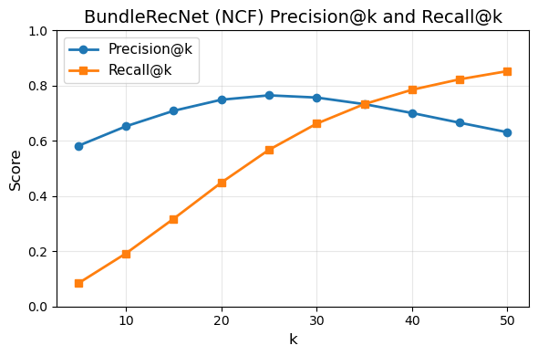

```python
ks = list(range(5, 55, 5))

recalls, precisions = test_recalls, test_precisions
recalls_d, precisions_d = recalls, precisions

plt.figure(figsize=(6,4))
plt.plot(ks, precisions, marker="o", label='Precision@k', linewidth=2)
plt.plot(ks, recalls, marker="s", label='Recall@k', linewidth=2)
plt.xlabel("k", fontsize=12)
plt.ylabel("Score", fontsize=12)
plt.title("BundleRecNet (NCF) Precision@k and Recall@k", fontsize=14)
plt.ylim(0, 1)
plt.legend(fontsize=11)
plt.grid(True, alpha=0.3)
plt.tight_layout()
plt.show()
```

## Results and Evaluation

### 1. Evaluation Metrics

To evaluate bundle recommendation quality, we use metrics designed for **implicit feedback ranking tasks**, where explicit ratings are not available and the goal is to rank positive bundles above negative ones.

#### AUC (Area Under the ROC Curve)

AUC measures how often the model ranks a positive bundle higher than a negative one. It is appropriate because:

- It directly evaluates *pairwise ranking*, which matches our training objective (BPR-style learning).
- It is insensitive to class imbalance, which is important because positives are extremely sparse.

#### Recall@K (Recall@10 and Recall@50)

Recall@K measures the proportion of the true positive bundle appears within the top-K recommended bundles.

Recall@K is appropriate because:

- It reflects **actual user-facing recommendation quality**, where only the top few results matter.
- It aligns with real-world deployment scenarios on platforms such as Steam, where users see a ranked list of recommendations.

#### Precision@K (Precision@10 and Precision@50)

Precision@K measures the presence of the false positives in the top-K list.

Precision@K is appropriate because:

- It tests on the ability of the model to avoid negative items.
- It backs up Recall@K with a confidence of high successful hit rate.

#### Why Accuracy maynot be a good choice?

Accuracy is misleading for recommendation tasks because:

- Equal Class Distribution: Positive and negative samples have the same number of instances in test data. Consequently, a model that outputs "positive" for everything would achieve an accuracy of 0.5, which signifies no predictive power.
- "Not chosen" does **not** mean "disliked"—it simply means "unobserved".

Therefore, AUC and Recall@K provide a more faithful evaluation for ranking quality and recommendation usefulness.

### 2. Baselines and Comparative Analysis

We compare several models ranging from simple baselines to more expressive neural architectures:

- **Logistic Regression**: A feature-based linear classifier serving as a simple baseline.
- **Bayesian Personalized Ranking (BPR)**: Stable bundle prediction with fixed item factors
- **Latent Factor Model (Matrix Factorization)**: Captures user–bundle interactions through learned embeddings.
- **Neural Collaborative Filtering (NCF)**: Learns nonlinear interactions via MLP layers.

By examining AUC and Recall@K, we can clearly see how each model improves over baselines.

### 3. Performance Comparison

[output not shown]

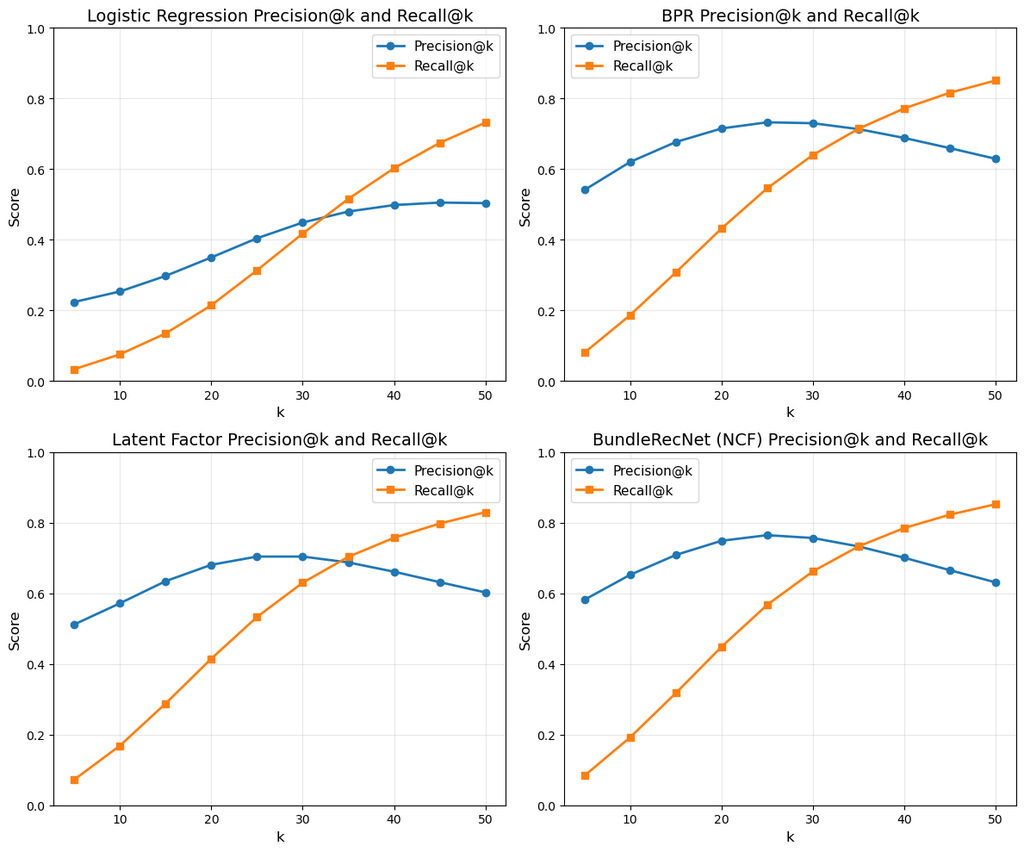

```python
ks = list(range(5, 55, 5))

fig, axes = plt.subplots(2, 2, figsize=(12, 10))  # 2 rows × 2 columns
axes = axes.flatten()  # flatten to 1D for easier indexing

axes[0].plot(ks, precisions_a, marker="o", label='Precision@k', linewidth=2)
axes[0].plot(ks, recalls_a, marker="s", label='Recall@k', linewidth=2)
axes[0].set_xlabel("k", fontsize=12)
axes[0].set_ylabel("Score", fontsize=12)
axes[0].set_title("Logistic Regression Precision@k and Recall@k", fontsize=14)
axes[0].set_ylim(0, 1)
axes[0].legend(fontsize=11)
axes[0].grid(True, alpha=0.3)

axes[1].plot(ks, precisions_b, marker="o", label='Precision@k', linewidth=2)
axes[1].plot(ks, recalls_b, marker="s", label='Recall@k', linewidth=2)
axes[1].set_xlabel("k", fontsize=12)
axes[1].set_ylabel("Score", fontsize=12)
axes[1].set_title("BPR Precision@k and Recall@k", fontsize=14)
axes[1].set_ylim(0, 1)
axes[1].legend(fontsize=11, loc="upper left")
axes[1].grid(True, alpha=0.3)

axes[2].plot(ks, precisions_c, marker="o", label='Precision@k', linewidth=2)
axes[2].plot(ks, recalls_c, marker="s", label='Recall@k', linewidth=2)
axes[2].set_xlabel("k", fontsize=12)
axes[2].set_ylabel("Score", fontsize=12)
axes[2].set_title("Latent Factor Precision@k and Recall@k", fontsize=14)
axes[2].set_ylim(0, 1)
axes[2].legend(fontsize=11)
axes[2].grid(True, alpha=0.3)

axes[3].plot(ks, precisions_d, marker="o", label='Precision@k', linewidth=2)
axes[3].plot(ks, recalls_d, marker="s", label='Recall@k', linewidth=2)
axes[3].set_xlabel("k", fontsize=12)
axes[3].set_ylabel("Score", fontsize=12)
axes[3].set_title("BundleRecNet (NCF) Precision@k and Recall@k", fontsize=14)
axes[3].set_ylim(0, 1)
axes[3].legend(fontsize=11, loc="upper left")
axes[3].grid(True, alpha=0.3)

plt.tight_layout()
plt.show()
```

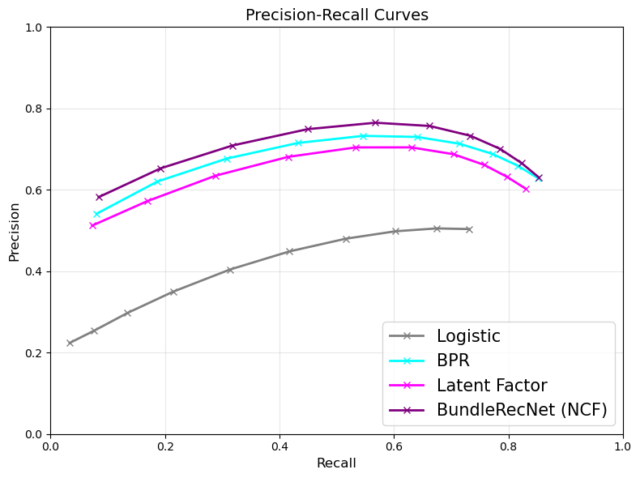

```python
plt.figure(figsize=(8,6))
plt.plot(recalls_a, precisions_a, color='gray', marker="x", label='Logistic', linewidth=2)
plt.plot(recalls_b, precisions_b, color='cyan', marker="x", label='BPR', linewidth=2)
plt.plot(recalls_c, precisions_c, color='magenta', marker="x", label='Latent Factor', linewidth=2)
plt.plot(recalls_d, precisions_d, color='purple', marker="x", label='BundleRecNet (NCF)', linewidth=2)
plt.xlabel("Recall", fontsize=12)
plt.ylabel("Precision", fontsize=12)
plt.title("Precision-Recall Curves", fontsize=14)
plt.xlim(0, 1)
plt.ylim(0, 1)
plt.legend(fontsize=15)
plt.grid(True, alpha=0.3)
plt.tight_layout()
plt.show()
```

### 4. Comments on Graphs

We combine the previous Precision@k and Recall@k graphs into one here. In addition, precision-recall curves are plotted for all models. We observe that all of BPR, latent factor, and BundleRecNet achieve a decent perfomace on precision and recall metrics. Although precisions are somewhat low on small k values, they return to normal in the mid range. Among all models, BundleRecNet gets the top, overarching other curves, followed by BPR. This aligns with our performance statistics where BundleRecNet boasts the best scores.

### 5. Discussion

#### 5.1 Model Performance Analysis

**Logistic Regression (Baseline)**

The logistic regression baseline demonstrates fundamentally limited capability for bundle recommendation tasks. With an AUC of only 0.502—barely distinguishable from random guessing (0.5)—and a Recall@10 of 0.076, the model fails to effectively rank relevant bundles. This poor performance reveals critical limitations of linear feature-based approaches in this domain:

- **Linearity Constraint**: Bundle recommendation involves complex, nonlinear interactions between user preferences and bundle characteristics that cannot be captured through simple linear combinations of features.
- **Feature Engineering Bottleneck**: The model relies on hand-crafted features that may not adequately represent the intricate patterns underlying user-bundle interactions, particularly when dealing with implicit feedback signals.
- **Cold Start Vulnerability**: Without learned representations, the model struggles with bundles or users that have sparse interaction histories.

Despite achieving a Recall@50 of 0.732, this metric is less meaningful given that users typically only consider a small number of top recommendations in practice. The model's inability to surface relevant bundles in the top 10 positions makes it unsuitable for real-world deployment.

**Bayesian Personalized Ranking (BPR)**

BPR demonstrates a dramatic improvement over the baseline, achieving an AUC of 0.760 (+51.4% relative gain), Recall@10 of 0.187 (+146% improvement), and Recall@50 of 0.851. This substantial performance boost validates several key design principles:

- **Pairwise Ranking Objective**: By directly optimizing for the relative ordering of observed (positive) versus unobserved (negative) bundles, BPR aligns the training objective with the evaluation metrics, leading to better ranking quality.
- **Implicit Feedback Modeling**: BPR's framework is specifically designed for scenarios with only positive feedback, treating unobserved interactions as negative signals rather than requiring explicit negative labels.
- **Collaborative Filtering Power**: The model successfully captures collaborative patterns—users with similar bundle purchase histories are likely to prefer similar future bundles.

The performance confirms that even relatively simple matrix factorization approaches, when properly optimized for ranking tasks, can substantially outperform feature-based methods. However, BPR's linear factorization limits its ability to model complex higher-order interactions.

**Latent Factor Model**

The latent factor model achieves further improvements with an AUC of 0.797 (+4.9% over BPR), demonstrating the value of learned embeddings in capturing user-bundle affinities. Interestingly, while this model achieves the highest AUC among non-neural approaches, its Recall@10 (0.169) is slightly lower than BPR's (0.187), though it maintains competitive Recall@50 (0.830).

Key observations:

- **Embedding Quality**: The learned latent representations encode rich semantic information about user preferences and bundle characteristics, enabling better discrimination between relevant and irrelevant bundles.
- **Metric Trade-offs**: The higher AUC but slightly lower Recall@10 suggests that the model excels at overall ranking quality (correctly ordering most pairs) but may be slightly less aggressive in promoting true positives to the very top positions.
- **Generalization**: The strong AUC indicates robust generalization, suggesting that the learned factors capture fundamental preference patterns rather than memorizing training data.

This model represents a sweet spot between complexity and performance, offering substantial gains over simple baselines while remaining computationally efficient and interpretable through its latent factor structure.

**BundleRecNet (Neural Collaborative Filtering)**

- **Nonlinear Interaction Modeling**: By combining Generalized Matrix Factorization (GMF) with Multi-Layer Perceptrons (MLP), BundleRecNet captures both linear and nonlinear user-bundle interactions. The MLP pathway learns complex feature interactions that simpler models cannot represent.
- **Multi-Pathway Architecture**: The dual-pathway design allows the model to simultaneously leverage different aspects of the data—GMF captures inner-product-based similarities while MLP learns arbitrary interaction functions.
- **Representation Learning**: Deep neural architectures learn hierarchical representations, with early layers capturing low-level patterns and deeper layers encoding higher-level abstractions about user preferences and bundle compositions.
- **Capacity and Expressiveness**: The additional parameters and nonlinear transformations provide the model with greater capacity to fit the complex distribution of user-bundle interactions.

The consistent improvements across all metrics—particularly the strong Recall@10 performance—indicate that BundleRecNet effectively prioritizes relevant bundles at the top of recommendation lists, which is crucial for user satisfaction in production systems.

#### 5.2 Practical Implications

The progression from simple to complex models reveals important insights for real-world recommendation system design:

1. **Ranking-Aware Objectives Matter**: The dramatic improvement from logistic regression to BPR highlights the importance of using ranking-specific loss functions for recommendation tasks.
2. **Nonlinearity is Essential**: The consistent gains from adding nonlinear modeling capacity (Latent Factor → BundleRecNet) demonstrate that user preferences involve complex patterns that require expressive models.
3. **Top-K Performance vs. Overall Ranking**: Different models show different strengths—some optimize overall ranking (higher AUC) while others excel at surfacing top results (higher Recall@10). Production systems should choose models based on their specific use case.
4. **Computational Trade-offs**: While BundleRecNet achieves the best performance, it requires significantly more training time and computational resources than simpler models like BPR. For applications with strict latency constraints or limited resources, the latent factor model or BPR may offer better cost-performance ratios.

#### 5.3 Limitations and Future Directions

Despite strong performance, several limitations suggest opportunities for future work:

- **Cold Start Problem**: All models struggle with new users or bundles with minimal interaction history. Incorporating content features (game genres, tags, descriptions) could improve cold-start performance.
- **Temporal Dynamics**: Current models treat all interactions equally regardless of when they occurred. Incorporating recency weighting or sequential modeling could capture evolving user preferences.
- **Bundle Composition**: Models don't explicitly reason about which items within a bundle drive user decisions or how item combinations affect bundle appeal. Graph neural networks or attention mechanisms could model these compositional effects.
- **Explainability**: Neural models offer limited interpretability. Attention-based architectures could provide insights into recommendation reasoning.
- **Scale**: Performance should be validated on larger datasets to assess scalability and generalization to broader user populations.

## Related Work

Prior work on recommendation has explored bundled item modeling, heterogeneous feedback signals, and sequential user behavior, all of which relate to the problem of personalized bundle recommendation.

**Bundle Recommendation and Steam Dataset Analysis**

Pathak et al. (2017) investigate the semantics of “good” bundles and the task of recommending or generating bundles tailored to individual users. Using a large-scale dataset collected from the Australian Steam community—comprising 88,310 gamers, 10,978 games, and 615 bundles—the authors show that bundles constitute a significant portion of user activity: one-third of users purchased at least one bundle, and bundled games account for roughly 70% of purchases despite only 25% of all games appearing in bundles. Their analysis highlights issues such as bundle size, item compatibility, and the frequent purchase of bundles containing items a user already owns, motivating the need for personalization. They build on latent factor methods, particularly Bayesian Personalized Ranking (BPR), to integrate bundle-specific features with traditional implicit-feedback recommendation.

**Modeling Multiple Feedback Signals**

Wan and McAuley (2018) study the interplay between implicit and explicit feedback signals—such as clicks, purchases, ratings, and reviews—arguing that real-world interactions naturally form monotonic behavior chains. They propose joint modeling approaches that leverage dense implicit signals to improve sparse explicit predictions (and vice versa), demonstrating performance gains across datasets with mixed interaction types. Their work emphasizes the value of exploiting structured dependencies among heterogeneous signals.

**Sequential Recommendation**

Kang and McAuley (2018) focus on capturing temporal dynamics in user behavior. Classical approaches such as Markov Chains rely on short-term transitions, while RNN-based methods aim to capture long-term patterns but at higher computational cost. SASRec, their self-attention–based model, balances these strengths by selectively attending to the most relevant past actions while still modeling long-range dependencies. The model achieves state-of-the-art performance across datasets of varying sparsity and offers interpretability through attention-weight visualization.

Together, these works demonstrate the importance of bundle-aware modeling, heterogeneous interaction signals, and temporal sequential patterns—three complementary perspectives relevant to personalized bundle recommendation.

## Conclusion

In this project, we addressed the task of personalized bundle recommendation on the Steam platform using the Australian Steam dataset. We explored four distinct modeling approaches—Logistic Regression, Bayesian Personalized Ranking (BPR), Latent Factor Model, and BundleRecNet (Neural Collaborative Filtering)—to predict whether a user would purchase a given bundle based on their historical interaction patterns.

The progression from simpler models to more sophisticated approaches highlights several key insights: (1) traditional feature-based methods struggle with the inherently nonlinear nature of bundle preferences, (2) implicit feedback modeling through BPR provides substantial improvements by leveraging pairwise ranking objectives, (3) latent factor models effectively capture collaborative filtering signals through learned embeddings, and (4) neural approaches that combine multiple representation pathways achieve the best performance by modeling deeper user-item interactions.

Future work could explore several promising directions, including: incorporating sequential patterns in user purchase behavior, integrating content-based features from game metadata (genres, tags, developers), modeling bundle composition and item compatibility more explicitly, and investigating multi-task learning approaches that jointly optimize for multiple interaction types. Additionally, attention mechanisms could be explored to better understand which bundle components drive user decisions, and graph neural networks could model the complex relationships between users, bundles, and individual items in a unified framework.

This work demonstrates that modern deep learning approaches to collaborative filtering can significantly improve bundle recommendation quality, offering practical value for platforms seeking to personalize bundle offerings and enhance user satisfaction while increasing sales through better-targeted recommendations.

## Citations

Kang, Wang-Cheng, and Julian McAuley. "Self-Attentive Sequential Recommendation." Proceedings of the IEEE International Conference on Data Mining (ICDM), 2018.

Wan, Mengting, and Julian McAuley. "Item Recommendation on Monotonic Behavior Chains." Proceedings of the ACM Conference on Recommender Systems (RecSys), 2018.

Pathak, Apurva, Kshitiz Gupta, and Julian McAuley. "Generating and Personalizing Bundle Recommendations on Steam." Proceedings of the ACM SIGIR Conference, 2017.